# ReneWind-NN-Project-Sriram-Narasimhan

[figure not shown]

Artificial Intelligence and Machine Learning

Neural Networks - Project

[figure not shown]

ReneWind : Renewable energy machinery

# **Problem Statement**

## Business Context

Renewable energy sources play an increasingly important role in the global energy mix, as the effort to reduce the environmental impact of energy production increases. Out of all the renewable energy alternatives, wind energy is one of the most developed technologies worldwide. The U.S. Department of Energy has put together a guide to achieving operational efficiency using predictive maintenance practices.

Predictive maintenance uses sensor information and analysis methods to measure and predict degradation and future component capability. The idea behind predictive maintenance is that failure patterns are predictable and if component failure can be predicted accurately and the component is replaced before it fails, the costs of operation and maintenance will be much lower.

The sensors fitted across different machines involved in the process of energy generation collect data related to various environmental factors (temperature, humidity, wind speed, etc.) and additional features related to various parts of the wind turbine (gearbox, tower, blades, break, etc.).

## Objective

"ReneWind" is a company working on improving the machinery/processes involved in the production of wind energy using machine learning and has collected data on generator failure of wind turbines using sensors.

The objective is to build various classification models, tune them, and find the best one that will help identify failures so that the generators can be repaired before failing/breaking to reduce the overall maintenance cost.

## Dataset

They have shared a ciphered version of the data, as the data collected through sensors is confidential (the type of data collected varies with companies).

Data has

1. 40 predictors
2. 20000 observations in the training set
3. 5000 observations in the test set.

### Target variable

- "1" in the target variable should be considered as "failure"
- "0" represents "No failure".

### Nature of predictions

The nature of predictions made by the classification model will translate as follows:

- True positives (TP) are failures correctly predicted by the model. These will result in repair costs.
- False negatives (FN) are real failures where there is no detection by the model. These will result in replacement costs.
- False positives (FP) are detections where there is no failure. These will result in inspection costs.

It is given that the cost of repairing a generator is much less than the cost of replacing it, and the cost of inspection is less than the cost of repair.

# **Importing the necessary libraries**

```python
# Library for data manipulation and analysis.
import pandas as pd

# Fundamental package for scientific computing.
import numpy as np

# splitting datasets into training and testing sets.
from sklearn.model_selection import train_test_split

# Imports tools for data preprocessing including label encoding, one-hot encoding, and standard scaling
from sklearn.preprocessing import LabelEncoder, OneHotEncoder,StandardScaler

# Imports a class for imputing missing values in datasets.
from sklearn.impute import SimpleImputer

# Imports util for handling class weights
from sklearn.utils import class_weight

#Imports the Matplotlib library for creating visualizations.
import matplotlib.pyplot as plt

# Imports the Seaborn library for statistical data visualization.
import seaborn as sns

# Time related functions.
import time

#Imports functions for evaluating the performance of machine learning models
from sklearn.metrics import confusion_matrix, f1_score,accuracy_score, recall_score, precision_score, classification_report

#Imports the tensorflow, keras and layers.
import tensorflow
import tensorflow as tf
from tensorflow.keras.models import Sequential
from tensorflow.keras.layers import Dense
from tensorflow.keras.layers import Dense, Activation, Input, Dropout, BatchNormalization
from tensorflow.keras import backend
from tensorflow.keras.metrics import Recall

# to suppress unnecessary warnings
import warnings
warnings.filterwarnings("ignore")
```

# **Tensorflow setup**

```python
# Set the seed using keras.utils.set_random_seed. This will set:
# 1) `numpy` seed
# 2) backend random seed
# 3) `python` random seed
tf.keras.utils.set_random_seed(812)

# If using TensorFlow, this will make GPU ops as deterministic as possible,
# but it will affect the overall performance, so be mindful of that.
tf.config.experimental.enable_op_determinism()
```

# **Loading the dataset**

## Training dataset

```python
# load the CSV file containing training data from local storage of colab notebook
sensor_training_data = pd.read_csv("Train.csv")

# copying training data to another variable as backup to avoid any changes to original data
data = sensor_training_data.copy()
```

## Test dataset

```python
# load the CSV file containing test data from local storage of colab notebook
sensor_test_data = pd.read_csv("Test.csv")

# copying test data to another variable as backup to avoid any changes to original data
test_data = sensor_test_data.copy()
```

# **1. Exploratory Data Analysis**

## Training Data oveview

### First and last 10 records

```python
#get the first 10 records in training dataset
data.head(10)
```

|  | V1 | V2 | V3 | V4 | V5 | V6 | V7 | V8 | V9 | V10 | ... | V32 | V33 | V34 | V35 | V36 | V37 | V38 | V39 | V40 | Target |
| --- | --- | --- | --- | --- | --- | --- | --- | --- | --- | --- | --- | --- | --- | --- | --- | --- | --- | --- | --- | --- | --- |
| 0 | -4.464606 | -4.679129 | 3.101546 | 0.506130 | -0.221083 | -2.032511 | -2.910870 | 0.050714 | -1.522351 | 3.761892 | ... | 3.059700 | -1.690440 | 2.846296 | 2.235198 | 6.667486 | 0.443809 | -2.369169 | 2.950578 | -3.480324 | 0 |
| 1 | 3.365912 | 3.653381 | 0.909671 | -1.367528 | 0.332016 | 2.358938 | 0.732600 | -4.332135 | 0.565695 | -0.101080 | ... | -1.795474 | 3.032780 | -2.467514 | 1.894599 | -2.297780 | -1.731048 | 5.908837 | -0.386345 | 0.616242 | 0 |
| 2 | -3.831843 | -5.824444 | 0.634031 | -2.418815 | -1.773827 | 1.016824 | -2.098941 | -3.173204 | -2.081860 | 5.392621 | ... | -0.257101 | 0.803550 | 4.086219 | 2.292138 | 5.360850 | 0.351993 | 2.940021 | 3.839160 | -4.309402 | 0 |
| 3 | 1.618098 | 1.888342 | 7.046143 | -1.147285 | 0.083080 | -1.529780 | 0.207309 | -2.493629 | 0.344926 | 2.118578 | ... | -3.584425 | -2.577474 | 1.363769 | 0.622714 | 5.550100 | -1.526796 | 0.138853 | 3.101430 | -1.277378 | 0 |
| 4 | -0.111440 | 3.872488 | -3.758361 | -2.982897 | 3.792714 | 0.544960 | 0.205433 | 4.848994 | -1.854920 | -6.220023 | ... | 8.265896 | 6.629213 | -10.068689 | 1.222987 | -3.229763 | 1.686909 | -2.163896 | -3.644622 | 6.510338 | 0 |
| 5 | 0.159623 | -4.233781 | -0.264310 | -5.477119 | -0.190854 | -0.356274 | -0.134486 | 4.066608 | -3.858569 | 1.692441 | ... | 3.227235 | 0.628900 | -1.548860 | 1.321979 | 5.461345 | 1.109410 | -3.869993 | 0.273964 | 2.805941 | 0 |
| 6 | -0.184565 | -4.721470 | 0.864988 | -3.078695 | -2.226888 | -1.282220 | -0.804717 | 3.289733 | -1.567971 | 0.749904 | ... | -0.544941 | -0.762921 | 0.815558 | 1.889373 | 3.624347 | 1.555740 | -5.432884 | 0.678703 | 0.464697 | 0 |
| 7 | 1.734840 | 1.682945 | -1.269070 | 4.600630 | -1.416975 | -2.543916 | 0.131648 | -0.198661 | 3.094057 | -1.109324 | ... | 1.717474 | -3.838931 | 1.569448 | 1.794899 | -4.268517 | -0.516195 | -0.619218 | -0.830889 | -4.967266 | 1 |
| 8 | 1.781583 | 1.314664 | 4.248690 | -0.518293 | -0.149044 | 0.033082 | -1.087893 | -3.117561 | 0.624935 | 1.567455 | ... | 1.611014 | 2.951390 | -1.862016 | 4.389598 | 1.371300 | -2.516235 | 0.770496 | 0.831132 | -2.310953 | 0 |
| 9 | -0.894140 | 4.011498 | 5.251902 | 3.320747 | 0.727067 | -4.771070 | 1.031232 | 3.632080 | -1.391444 | -1.966746 | ... | -0.635742 | -4.449139 | 2.296340 | 1.575110 | 1.376268 | 0.596757 | -1.413652 | 0.543871 | 0.035020 | 0 |

10 rows × 41 columns

```python
# get the last 10 records in training dataset
data.tail(10)
```

|  | V1 | V2 | V3 | V4 | V5 | V6 | V7 | V8 | V9 | V10 | ... | V32 | V33 | V34 | V35 | V36 | V37 | V38 | V39 | V40 | Target |
| --- | --- | --- | --- | --- | --- | --- | --- | --- | --- | --- | --- | --- | --- | --- | --- | --- | --- | --- | --- | --- | --- |
| 19990 | -0.579836 | -2.629670 | 0.474419 | -2.671421 | -2.323783 | -1.830285 | -0.112126 | 3.581327 | -1.085178 | -1.369451 | ... | -1.940408 | -0.769011 | 0.802292 | 1.814545 | 1.657435 | 2.424586 | -4.565140 | 0.827243 | 0.228813 | 0 |
| 19991 | 6.826134 | 3.141716 | 6.575012 | -4.684994 | -1.978555 | 1.552752 | 1.268366 | -5.975145 | 0.297224 | 2.047525 | ... | -7.818127 | 0.765248 | -0.539477 | 4.031437 | 2.270127 | -2.454773 | 5.460646 | 2.018346 | 0.081557 | 0 |
| 19992 | -0.730383 | -8.463166 | 1.111823 | -8.918874 | -2.309441 | 2.902515 | -4.203021 | -3.019003 | -0.093653 | 2.472905 | ... | -2.711114 | 3.624536 | -3.264870 | 2.393250 | 7.795103 | 2.312051 | -3.950337 | 3.226444 | 1.138433 | 0 |
| 19993 | 0.250887 | -5.068987 | 5.866389 | -5.048788 | -1.226417 | -2.077842 | -3.638690 | 0.940573 | 0.851951 | 0.056203 | ... | -2.642109 | -2.768446 | -2.611676 | 1.853566 | 9.387797 | 2.556526 | -9.389720 | 2.845682 | 1.878341 | 0 |
| 19994 | -2.546629 | -2.370481 | -0.728626 | -0.947777 | 1.417739 | -2.489878 | -0.820629 | 4.790304 | -2.949182 | 0.209342 | ... | 5.798262 | -2.451336 | -0.697349 | 0.460678 | 4.298600 | 1.973705 | -3.613722 | 0.165335 | 1.342830 | 0 |
| 19995 | -2.071318 | -1.088279 | -0.796174 | -3.011720 | -2.287540 | 2.807310 | 0.481428 | 0.105171 | -0.586599 | -2.899398 | ... | -8.273996 | 5.745013 | 0.589014 | -0.649988 | -3.043174 | 2.216461 | 0.608723 | 0.178193 | 2.927755 | 1 |
| 19996 | 2.890264 | 2.483069 | 5.643919 | 0.937053 | -1.380870 | 0.412051 | -1.593386 | -5.762498 | 2.150096 | 0.272302 | ... | -4.159092 | 1.181466 | -0.742412 | 5.368979 | -0.693028 | -1.668971 | 3.659954 | 0.819863 | -1.987265 | 0 |
| 19997 | -3.896979 | -3.942407 | -0.351364 | -2.417462 | 1.107546 | -1.527623 | -3.519882 | 2.054792 | -0.233996 | -0.357687 | ... | 7.112162 | 1.476080 | -3.953710 | 1.855555 | 5.029209 | 2.082588 | -6.409304 | 1.477138 | -0.874148 | 0 |
| 19998 | -3.187322 | -10.051662 | 5.695955 | -4.370053 | -5.354758 | -1.873044 | -3.947210 | 0.679420 | -2.389254 | 5.456756 | ... | 0.402812 | 3.163661 | 3.752095 | 8.529894 | 8.450626 | 0.203958 | -7.129918 | 4.249394 | -6.112267 | 0 |
| 19999 | -2.686903 | 1.961187 | 6.137088 | 2.600133 | 2.657241 | -4.290882 | -2.344267 | 0.974004 | -1.027462 | 0.497421 | ... | 6.620811 | -1.988786 | -1.348901 | 3.951801 | 5.449706 | -0.455411 | -2.202056 | 1.678229 | -1.974413 | 0 |

10 rows × 41 columns

**Observations :**

- All the columns are ciphered with names sequenced with prefix V as V1, V2 .. V40
- The predictor columns are all continuos, with ranging magnitude and higher precision
- There are no categories, but actual measured quantities are present as numeric.
- Data appears to be preprocessed/standardized (possibly z-score normalized), and could be the reason the values are centered around 0 with both positive and negative values.
- The Target variable (0 and 1) is the only discrete/categorical variable, representing "No failure" (0) and "Failure" (1)

### Shape of the dataset.

```python
# get the shape of training data
data.shape
```

```
(20000, 41)
```

- The application dataset has 20000 rows and 41 columns in the training dataset

### Data types of the columns

```python
# get training data info
data.info()
```

```
<class 'pandas.core.frame.DataFrame'>
RangeIndex: 20000 entries, 0 to 19999
Data columns (total 41 columns):
 #   Column  Non-Null Count  Dtype
---  ------  --------------  -----
 0   V1      19982 non-null  float64
 1   V2      19982 non-null  float64
 2   V3      20000 non-null  float64
 3   V4      20000 non-null  float64
 4   V5      20000 non-null  float64
 5   V6      20000 non-null  float64
 6   V7      20000 non-null  float64
 7   V8      20000 non-null  float64
 8   V9      20000 non-null  float64
 9   V10     20000 non-null  float64
```

[output cut: 33 more lines]

**Observations :**

- All the 40 predictor columns are of type float64
- The target variable column is of type int64

### Statistical summary of the dataset.

```python
# display the statistical summary of all columns
data.describe(include='all').T
```

|  | count | mean | std | min | 25% | 50% | 75% | max |
| --- | --- | --- | --- | --- | --- | --- | --- | --- |
| V1 | 19982.0 | -0.271996 | 3.441625 | -11.876451 | -2.737146 | -0.747917 | 1.840112 | 15.493002 |
| V2 | 19982.0 | 0.440430 | 3.150784 | -12.319951 | -1.640674 | 0.471536 | 2.543967 | 13.089269 |
| V3 | 20000.0 | 2.484699 | 3.388963 | -10.708139 | 0.206860 | 2.255786 | 4.566165 | 17.090919 |
| V4 | 20000.0 | -0.083152 | 3.431595 | -15.082052 | -2.347660 | -0.135241 | 2.130615 | 13.236381 |
| V5 | 20000.0 | -0.053752 | 2.104801 | -8.603361 | -1.535607 | -0.101952 | 1.340480 | 8.133797 |
| V6 | 20000.0 | -0.995443 | 2.040970 | -10.227147 | -2.347238 | -1.000515 | 0.380330 | 6.975847 |
| V7 | 20000.0 | -0.879325 | 1.761626 | -7.949681 | -2.030926 | -0.917179 | 0.223695 | 8.006091 |
| V8 | 20000.0 | -0.548195 | 3.295756 | -15.657561 | -2.642665 | -0.389085 | 1.722965 | 11.679495 |
| V9 | 20000.0 | -0.016808 | 2.160568 | -8.596313 | -1.494973 | -0.067597 | 1.409203 | 8.137580 |
| V10 | 20000.0 | -0.012998 | 2.193201 | -9.853957 | -1.411212 | 0.100973 | 1.477045 | 8.108472 |
| V11 | 20000.0 | -1.895393 | 3.124322 | -14.832058 | -3.922404 | -1.921237 | 0.118906 | 11.826433 |
| V12 | 20000.0 | 1.604825 | 2.930454 | -12.948007 | -0.396514 | 1.507841 | 3.571454 | 15.080698 |
| V13 | 20000.0 | 1.580486 | 2.874658 | -13.228247 | -0.223545 | 1.637185 | 3.459886 | 15.419616 |
| V14 | 20000.0 | -0.950632 | 1.789651 | -7.738593 | -2.170741 | -0.957163 | 0.270677 | 5.670664 |
| V15 | 20000.0 | -2.414993 | 3.354974 | -16.416606 | -4.415322 | -2.382617 | -0.359052 | 12.246455 |
| V16 | 20000.0 | -2.925225 | 4.221717 | -20.374158 | -5.634240 | -2.682705 | -0.095046 | 13.583212 |
| V17 | 20000.0 | -0.134261 | 3.345462 | -14.091184 | -2.215611 | -0.014580 | 2.068751 | 16.756432 |
| V18 | 20000.0 | 1.189347 | 2.592276 | -11.643994 | -0.403917 | 0.883398 | 2.571770 | 13.179863 |
| V19 | 20000.0 | 1.181808 | 3.396925 | -13.491784 | -1.050168 | 1.279061 | 3.493299 | 13.237742 |
| V20 | 20000.0 | 0.023608 | 3.669477 | -13.922659 | -2.432953 | 0.033415 | 2.512372 | 16.052339 |
| V21 | 20000.0 | -3.611252 | 3.567690 | -17.956231 | -5.930360 | -3.532888 | -1.265884 | 13.840473 |
| V22 | 20000.0 | 0.951835 | 1.651547 | -10.122095 | -0.118127 | 0.974687 | 2.025594 | 7.409856 |
| V23 | 20000.0 | -0.366116 | 4.031860 | -14.866128 | -3.098756 | -0.262093 | 2.451750 | 14.458734 |
| V24 | 20000.0 | 1.134389 | 3.912069 | -16.387147 | -1.468062 | 0.969048 | 3.545975 | 17.163291 |
| V25 | 20000.0 | -0.002186 | 2.016740 | -8.228266 | -1.365178 | 0.025050 | 1.397112 | 8.223389 |
| V26 | 20000.0 | 1.873785 | 3.435137 | -11.834271 | -0.337863 | 1.950531 | 4.130037 | 16.836410 |
| V27 | 20000.0 | -0.612413 | 4.368847 | -14.904939 | -3.652323 | -0.884894 | 2.189177 | 17.560404 |
| V28 | 20000.0 | -0.883218 | 1.917713 | -9.269489 | -2.171218 | -0.891073 | 0.375884 | 6.527643 |
| V29 | 20000.0 | -0.985625 | 2.684365 | -12.579469 | -2.787443 | -1.176181 | 0.629773 | 10.722055 |
| V30 | 20000.0 | -0.015534 | 3.005258 | -14.796047 | -1.867114 | 0.184346 | 2.036229 | 12.505812 |
| V31 | 20000.0 | 0.486842 | 3.461384 | -13.722760 | -1.817772 | 0.490304 | 2.730688 | 17.255090 |
| V32 | 20000.0 | 0.303799 | 5.500400 | -19.876502 | -3.420469 | 0.052073 | 3.761722 | 23.633187 |
| V33 | 20000.0 | 0.049825 | 3.575285 | -16.898353 | -2.242857 | -0.066249 | 2.255134 | 16.692486 |
| V34 | 20000.0 | -0.462702 | 3.183841 | -17.985094 | -2.136984 | -0.255008 | 1.436935 | 14.358213 |
| V35 | 20000.0 | 2.229620 | 2.937102 | -15.349803 | 0.336191 | 2.098633 | 4.064358 | 15.291065 |
| V36 | 20000.0 | 1.514809 | 3.800860 | -14.833178 | -0.943809 | 1.566526 | 3.983939 | 19.329576 |
| V37 | 20000.0 | 0.011316 | 1.788165 | -5.478350 | -1.255819 | -0.128435 | 1.175533 | 7.467006 |
| V38 | 20000.0 | -0.344025 | 3.948147 | -17.375002 | -2.987638 | -0.316849 | 2.279399 | 15.289923 |
| V39 | 20000.0 | 0.890653 | 1.753054 | -6.438880 | -0.272250 | 0.919261 | 2.057540 | 7.759877 |
| V40 | 20000.0 | -0.875630 | 3.012155 | -11.023935 | -2.940193 | -0.920806 | 1.119897 | 10.654265 |
| Target | 20000.0 | 0.055500 | 0.228959 | 0.000000 | 0.000000 | 0.000000 | 0.000000 | 1.000000 |

#### Observations

**Mean and Standard Deviation :**

- Most variables have means close to 0 (ranging -3.61 to 2.48)
- Standard deviations are relatively similar (ranging 1.6 to 5.5)
- Data has been preprocessed (likely z-score normalization or similar)

**Target variable & Dataset balance**

**Missing Values**

- V1 and V2 have only 18 missing values each and the remaining 38 variables do not have any missing.

**Data characteristics**

- The variables appear to have different ranges e.g., V37: -5.48 to 7.47 vs V32: -19.88 to 23.63
- Mean and Median are close to each other for most of the variables, displaying symmetry of the distribution

## Univariate Analysis

Note : Univariate analysis will be only performed on training data. Performing any analysis on test data could leak and the test data will remain unseen and untouched to provide an unbiased evaluation

### Numerical (continuous) variables and histogram

- Univariate analysis may NOT be useful for this dataset. Some of the reasons being,
  - V1, V2, V3...V40 have no business meaning. The distribution shapes won't provide insights
  - Data appears standardized/normalized. The original distributions are already transformed
- Still to ensure the understanding is correct, histogram with KDE will be plotted for all 40 variables
- There are no categorical variables and hence only one type of plot (histogram with KDE) will be used to evaluate

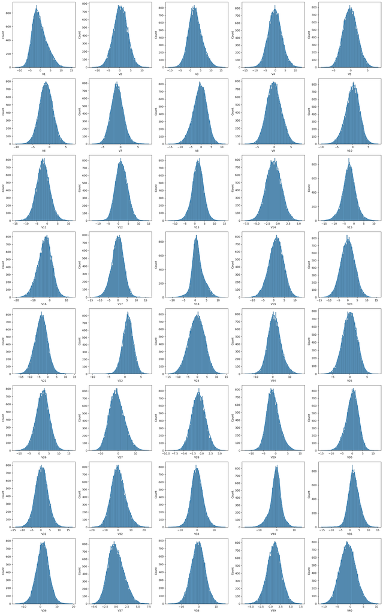

```python
# Define the plot figure size
plt.figure(figsize=(20, 32))

# Get all feature columns (V1 to V40)
features = [f'V{i}' for i in range(1, 41)]

# plotting the histogram for each numerical feature
for i, feature in enumerate(features):
    # assign a subplot in the main plot
    plt.subplot(8, 5, i+1)

    # plot the histogram on log scale
    sns.histplot(data=data, x=feature, kde=True, alpha=0.7)

plt.tight_layout();   # to add spacing between plots
plt.show()
```

### Key Insights from Univariate Analysis

- All 40 variables show clean normal distributions
- Smooth bell curve suggests the dataset is clean
- Proper standardization/normalization techniques have been applied to this data and are nearly ready for the neural network to process (as Neural networks perform best with normalised data)

## Bivariate Analysis

### Correlation with target using horizontal bar plot

- Similar challenges observed in univariate analysis might still persist with bivariate analysis too, as the data is already preprocessed.
- The variable names are masked leading to no meaningful interpretation
- Hence, the variables will only be correlated with target variable and a horizontal bar plot will be drawn
- Heatmap will not be used as readability will be hard, given there are 40 variables

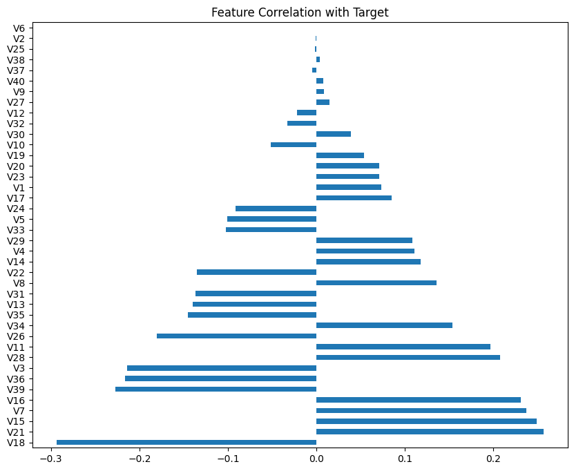

```python
# computes correlation coefficients between all features and the 'Target', drop target and sort by absolute value
target_corr = data.corr()['Target'].drop('Target').sort_values(key=abs, ascending=False)

# plot horizontal bar chart for the sorted correlation values
plt.figure(figsize=(10, 8))
target_corr.plot(kind='barh')
plt.title('Feature Correlation with Target')
```

### Key Insights from Bivariate Analysis

**Correlation Direction:**

- Right side (positive): Features positively correlated with failures
- Left side (negative): Features negatively correlated with failures
- Center (near 0): Features with little linear relationship to failures

**Most Important Features for Failure Prediction:**

**Conclusion**

# **2. Data pre-processing**

## Missing value detection

```python
# check for missing values
data.isnull().sum()
```

```
V1        18
V2        18
V3         0
V4         0
V5         0
V6         0
V7         0
V8         0
V9         0
V10        0
V11        0
V12        0
V13        0
V14        0
V15        0
V16        0
V17        0
V18        0
V19        0
V20        0
V21        0
V22        0
V23        0
V24        0
V25        0
V26        0
V27        0
V28        0
V29        0
V30        0
V31        0
V32        0
V33        0
V34        0
V35        0
V36        0
V37        0
V38        0
V39        0
V40        0
Target     0
dtype: int64
```

**Observations**

- V1 and V2 have 18 missing values and rest of the attributed do not have any missing
- V1 and V2 will be imputed in the 'prepare data for modelling' section. Given the relatively small number of missing values, and the data being already standardized, mean will be used for imputing.
- Also V1 (slightly) and V2 have normal distribution with good symmetry around the center. So mean imputation will be considered

## Duplicate value detection

```python
#check for duplicates in training data
data.duplicated().sum()
```

```
np.int64(0)
```

**Observations**

- There are no duplicate values in the data and hence treatment is not required

## Prepare data for modelling

### Split training data to train, validation

```python
# split training data to features and target
X = data.drop("Target", axis=1)
y = data["Target"]

# split train into train, val with 20% and stratified
X_train, X_val, y_train, y_val = train_test_split(X, y, test_size=0.2, stratify=y, random_state=42)
```

### Split test data to features, target

```python
# create X,y for test data
X_test = test_data.drop("Target", axis=1)
y_test = test_data["Target"]
```

### Impute missing values

- Mean imputer used
- Imputer is fitted only on training data
- Same fitted imputer is used to transform validation and test data

```python
# impute missing values using mean (reasons provided in missing value detection)
imputer = SimpleImputer(strategy='mean')

# Columns to impute
cols_to_impute = ["V1", "V2"]

# Fit on train data
X_train[cols_to_impute] = imputer.fit_transform(X_train[cols_to_impute])

# Transform val and test data
X_val[cols_to_impute] = imputer.transform(X_val[cols_to_impute])
X_test[cols_to_impute] = imputer.transform(X_test[cols_to_impute])
```

### Standardize the data using Scaler

- Histograms from Univariate analysis show normal-like distributions, but the statistical summary also showed that the features are not on the same scale. Hence, the data will be standardized as Neural networks require consistent scaling across all features (mean=0, std=1) for optimal performance.
- Training Data will be applied with `fit_transform` and test data with `transform`. This will avoids using information from the test set when scaling, and will **prevent data leakage**.

```python
# Instantiate StandardScaler
scaler = StandardScaler()

# Fit transform and scale Training data
X_train_normalized = scaler.fit_transform(X_train)

# Transform val and test data.
X_val_normalized = scaler.transform(X_val)
X_test_normalized = scaler.transform(X_test)
```

# **3. Model Building**

## Model Evaluation Criterion

### Possible predictions

1. **True Positives (TP)**: Failures are predicted correctly. This results in 'Repair costs' and the components are repaired or replaced before failure
2. **False Negatives (FN)**: Model fails to predict Failures. This could result in 'Replacement costs' (i.e., the component fails unexpectedly, requiring emergency replacement)
3. **False Positives (FP)**: Model predicts failures but they are false alarms. This results in 'Inspection costs' (an inspection that was not necessary)

### Cost Hierarchy

Replacement cost (FN) **>** Repair cost (TP) **>** Inspection cost (FP)

### What does ReneWind want ?

Following is the 'Key Insight from Predictive Maintenance' that ReneWind expects.

> Model should predict a failure correctly (TP), so that a **component can be repaired or replaced proactively at lower cost**, rather than waiting for it to fail catastrophically.

### Metric of Choice

Metric of Choice here is **'Recall'**

**Why Recall is Still the Right Choice**

- False Negatives are still the most expensive.
  - Missing a real failure means the turbine fails unexpectedly, requiring emergency replacement
- True Positives result in planned maintenance
  - Much cheaper than emergency replacement
- False Positives are manageable
  - Inspection costs are the lowest
- The dataset is imbalanced with only 5.5% positive cases. Missing them (False Negatives) would be particularly costly

**Summary** : Recall ensures we catch as many real failures as possible before they become catastrophic, which is exactly what predictive maintenance aims to achieve.

## Handling class imbalance

- Class weights will be used to handle the class imbalance in the dataset.
- Dataset has very low failures i.e., ~5.55% failures and high non-failures i.e., ~94.45% non-failures
- [Class weighing](https://scikit-learn.org/stable/modules/generated/sklearn.utils.class_weight.compute_class_weight.html) is the approach that will be used to handle the class imbalance

```python
# compute class weights using 'balanced' option
class_weights = class_weight.compute_class_weight(
    'balanced', classes=np.unique(y_train), y=y_train
)
# create a dictionary using the computed class weights
class_weight_dict = {i: class_weights[i] for i in range(len(class_weights))}
class_weight_dict
```

```
{0: np.float64(0.5293806246691372), 1: np.float64(9.00900900900901)}
```

## Initializing common variables

Following common variables that will be used in all models are initialized here

```python
epochs = 50
batch_size = 64
```

## Initializing result

- results variable is initialised to store the neural network design related attributes (hyper parameters) and the output from training

```python
columns = ["model_name",
           "hidden_layers",
           "hidden_layer_neurons",
           "hidden_layer_activations",
           "epochs",
           "batch_size",
           "optimizer",
           "learning_rate, momentum",
           "kernel_weights_init",
           "regularization",
           "train_loss",
           "validation_loss",
           "train_recall",
           "validation_recall",
           "duration"
]
results = pd.DataFrame(columns=columns)
```

## Utility functions

### Plot metric

```python
def plot_metric(history, name):
    """
    Function to plot loss/accuracy

    history: an object which stores the metrics and losses.
    name: can be one of Loss or Accuracy
    """
    #Creating a subplot with figure and axes.
    fig, ax = plt.subplots()

    #Plotting the train accuracy or train loss
    plt.plot(history.history[name])

    #Plotting the validation accuracy or validation loss
    plt.plot(history.history['val_'+name])

    #Defining the title of the plot.
    plt.title('Model ' + name.capitalize())


    #Capitalizing the first letter.
    plt.ylabel(name.capitalize())

    #Defining the label for the x-axis.
    plt.xlabel('Epoch')

    #Defining the legend, loc controls the position of the legend.
    fig.legend(['Train', 'Validation'], loc="outside right upper")
```

### Confusion matrix (train, validation)

```python
# function to plot the confusion matrix of training and validation, side by side
def plot_confusion_matrices_v2(model, training_predictors, training_target,
                               validation_predictors, validation_target,
                               validation_label = 'Validation Confusion Matrix'):
    """
    Plots side-by-side confusion matrices for training and validation datasets.

    model: trained classifier
    training_predictors, training_target: training features and labels
    validation_predictors, validation_target: validation features and labels
    """
    # Get predictions
    y_train_pred = (model.predict(X_train_normalized) > 0.5).astype(int)
    y_val_pred = (model.predict(X_val_normalized) > 0.5).astype(int)

    # Create confusion matrices
    cm_train = confusion_matrix(y_train, y_train_pred)
    cm_val = confusion_matrix(y_val, y_val_pred)

    # Plot side by side
    fig, axes = plt.subplots(1, 2, figsize=(10,4))

    # Training confusion matrix
    sns.heatmap(cm_train, annot=True, fmt='', ax=axes[0])
    axes[0].set_title('Training Confusion Matrix')
    axes[0].set_xlabel('Predicted')
    axes[0].set_ylabel('Actual')

    # Validation confusion matrix
    sns.heatmap(cm_val, annot=True, fmt='d', ax=axes[1])
    axes[1].set_title('Validation Confusion Matrix')
    axes[1].set_xlabel('Predicted')
    axes[1].set_ylabel('Actual')

    plt.tight_layout()
    plt.show()
```

## Model 1 : 'SGD' optimiser

```python
# clears the current Keras session, resets all layers, models previously created
tf.keras.backend.clear_session()
```

### Create Model

A neural network model will be built using

- 'hidden layer1' with 128 neurons, ReLU activation
- 'hidden layer2' with 64 neurons, ReLU activation
- optimiser as 'SGD'
- loss function as 'binary_crossentropy'
- output layer with 'sigmoid' activation
- optimiser : SGD

```python
#Initializing the neural network
model1 = Sequential()
model1.add(Input(shape=(X_train_normalized.shape[1],)))

# add hidden with 128, 64
model1.add(Dense(128,activation='relu'))
model1.add(Dense(64,activation='relu'))

# sigmoid output
model1.add(Dense(1,activation='sigmoid'))
print(model1.summary())

# defining SGD optimizer
optimizer = tf.keras.optimizers.SGD()

# compile with binary_crossentropy loss and SGD
model1.compile(loss='binary_crossentropy', optimizer=optimizer, metrics=['recall'])
```

```
Model: "sequential"
```

```
┏━━━━━━━━━━━━━━━━━━━━━━━━━━━━━━━━━┳━━━━━━━━━━━━━━━━━━━━━━━━┳━━━━━━━━━━━━━━━┓
┃ Layer (type)                    ┃ Output Shape           ┃       Param # ┃
┡━━━━━━━━━━━━━━━━━━━━━━━━━━━━━━━━━╇━━━━━━━━━━━━━━━━━━━━━━━━╇━━━━━━━━━━━━━━━┩
│ dense (Dense)                   │ (None, 128)            │         5,248 │
├─────────────────────────────────┼────────────────────────┼───────────────┤
│ dense_1 (Dense)                 │ (None, 64)             │         8,256 │
├─────────────────────────────────┼────────────────────────┼───────────────┤
│ dense_2 (Dense)                 │ (None, 1)              │            65 │
└─────────────────────────────────┴────────────────────────┴───────────────┘
```

```
 Total params: 13,569 (53.00 KB)
```

```
 Trainable params: 13,569 (53.00 KB)
```

```
 Non-trainable params: 0 (0.00 B)
```

```
None
```

### Training the model

- class weights are provided during training the model as the data is imbalanced

```python
# fit the model and capture start, end times
start = time.time()
history1 = model1.fit(X_train_normalized, y_train,
                    validation_data=(X_val_normalized, y_val) ,
                    batch_size=batch_size,
                    epochs=epochs,
                    class_weight=class_weight_dict)
end=time.time()

print("Time taken in seconds ",end-start)
```

```
250/250 ━━━━━━━━━━━━━━━━━━━━ 0s 706us/step - loss: 0.5634 - recall: 0.8726 - val_loss: 0.4498 - val_recall: 0.8964
250/250 ━━━━━━━━━━━━━━━━━━━━ 0s 429us/step - loss: 0.3564 - recall: 0.8793 - val_loss: 0.3363 - val_recall: 0.9099
  1/250 ━━━━━━━━━━━━━━━━━━━━ 1s 6ms/step - loss: 0.2084 - recall: 0.0000e+00
```

```
250/250 ━━━━━━━━━━━━━━━━━━━━ 0s 447us/step - loss: 0.3007 - recall: 0.8930 - val_loss: 0.2862 - val_recall: 0.9189
250/250 ━━━━━━━━━━━━━━━━━━━━ 0s 440us/step - loss: 0.2726 - recall: 0.9003 - val_loss: 0.2562 - val_recall: 0.9189
250/250 ━━━━━━━━━━━━━━━━━━━━ 0s 429us/step - loss: 0.2541 - recall: 0.9009 - val_loss: 0.2357 - val_recall: 0.9144
250/250 ━━━━━━━━━━━━━━━━━━━━ 0s 426us/step - loss: 0.2405 - recall: 0.9058 - val_loss: 0.2213 - val_recall: 0.9099
250/250 ━━━━━━━━━━━━━━━━━━━━ 0s 426us/step - loss: 0.2298 - recall: 0.9047 - val_loss: 0.2102 - val_recall: 0.9144
250/250 ━━━━━━━━━━━━━━━━━━━━ 0s 422us/step - loss: 0.2212 - recall: 0.9072 - val_loss: 0.2018 - val_recall: 0.9144
250/250 ━━━━━━━━━━━━━━━━━━━━ 0s 434us/step - loss: 0.2139 - recall: 0.9072 - val_loss: 0.1937 - val_recall: 0.9144
250/250 ━━━━━━━━━━━━━━━━━━━━ 0s 426us/step - loss: 0.2075 - recall: 0.9077 - val_loss: 0.1869 - val_recall: 0.9144
250/250 ━━━━━━━━━━━━━━━━━━━━ 0s 423us/step - loss: 0.2015 - recall: 0.9083 - val_loss: 0.1805 - val_recall: 0.9144
250/250 ━━━━━━━━━━━━━━━━━━━━ 0s 428us/step - loss: 0.1961 - recall: 0.9083 - val_loss: 0.1753 - val_recall: 0.9144
250/250 ━━━━━━━━━━━━━━━━━━━━ 0s 417us/step - loss: 0.1912 - recall: 0.9083 - val_loss: 0.1710 - val_recall: 0.9144
250/250 ━━━━━━━━━━━━━━━━━━━━ 0s 425us/step - loss: 0.1869 - recall: 0.9083 - val_loss: 0.1670 - val_recall: 0.9144
250/250 ━━━━━━━━━━━━━━━━━━━━ 0s 421us/step - loss: 0.1828 - recall: 0.9097 - val_loss: 0.1630 - val_recall: 0.9144
250/250 ━━━━━━━━━━━━━━━━━━━━ 0s 435us/step - loss: 0.1791 - recall: 0.9097 - val_loss: 0.1605 - val_recall: 0.9144
250/250 ━━━━━━━━━━━━━━━━━━━━ 0s 452us/step - loss: 0.1756 - recall: 0.9112 - val_loss: 0.1578 - val_recall: 0.9144
250/250 ━━━━━━━━━━━━━━━━━━━━ 0s 453us/step - loss: 0.1724 - recall: 0.9119 - val_loss: 0.1553 - val_recall: 0.9144
250/250 ━━━━━━━━━━━━━━━━━━━━ 0s 460us/step - loss: 0.1694 - recall: 0.9119 - val_loss: 0.1534 - val_recall: 0.9144
250/250 ━━━━━━━━━━━━━━━━━━━━ 0s 459us/step - loss: 0.1666 - recall: 0.9119 - val_loss: 0.1516 - val_recall: 0.9144
250/250 ━━━━━━━━━━━━━━━━━━━━ 0s 456us/step - loss: 0.1638 - recall: 0.9119 - val_loss: 0.1506 - val_recall: 0.9189
250/250 ━━━━━━━━━━━━━━━━━━━━ 0s 455us/step - loss: 0.1612 - recall: 0.9127 - val_loss: 0.1481 - val_recall: 0.9189
250/250 ━━━━━━━━━━━━━━━━━━━━ 0s 455us/step - loss: 0.1588 - recall: 0.9144 - val_loss: 0.1474 - val_recall: 0.9189
250/250 ━━━━━━━━━━━━━━━━━━━━ 0s 463us/step - loss: 0.1565 - recall: 0.9144 - val_loss: 0.1458 - val_recall: 0.9189
250/250 ━━━━━━━━━━━━━━━━━━━━ 0s 448us/step - loss: 0.1542 - recall: 0.9144 - val_loss: 0.1453 - val_recall: 0.9189
250/250 ━━━━━━━━━━━━━━━━━━━━ 0s 458us/step - loss: 0.1521 - recall: 0.9144 - val_loss: 0.1436 - val_recall: 0.9189
250/250 ━━━━━━━━━━━━━━━━━━━━ 0s 450us/step - loss: 0.1501 - recall: 0.9144 - val_loss: 0.1429 - val_recall: 0.9189
250/250 ━━━━━━━━━━━━━━━━━━━━ 0s 451us/step - loss: 0.1481 - recall: 0.9144 - val_loss: 0.1422 - val_recall: 0.9189
250/250 ━━━━━━━━━━━━━━━━━━━━ 0s 456us/step - loss: 0.1464 - recall: 0.9144 - val_loss: 0.1417 - val_recall: 0.9189
250/250 ━━━━━━━━━━━━━━━━━━━━ 0s 457us/step - loss: 0.1445 - recall: 0.9154 - val_loss: 0.1399 - val_recall: 0.9189
250/250 ━━━━━━━━━━━━━━━━━━━━ 0s 457us/step - loss: 0.1426 - recall: 0.9168 - val_loss: 0.1386 - val_recall: 0.9189
250/250 ━━━━━━━━━━━━━━━━━━━━ 0s 464us/step - loss: 0.1408 - recall: 0.9173 - val_loss: 0.1381 - val_recall: 0.9189
250/250 ━━━━━━━━━━━━━━━━━━━━ 0s 471us/step - loss: 0.1391 - recall: 0.9173 - val_loss: 0.1379 - val_recall: 0.9189
250/250 ━━━━━━━━━━━━━━━━━━━━ 0s 468us/step - loss: 0.1375 - recall: 0.9185 - val_loss: 0.1372 - val_recall: 0.9189
250/250 ━━━━━━━━━━━━━━━━━━━━ 0s 469us/step - loss: 0.1360 - recall: 0.9188 - val_loss: 0.1364 - val_recall: 0.9189
250/250 ━━━━━━━━━━━━━━━━━━━━ 0s 480us/step - loss: 0.1345 - recall: 0.9210 - val_loss: 0.1359 - val_recall: 0.9189
250/250 ━━━━━━━━━━━━━━━━━━━━ 0s 454us/step - loss: 0.1329 - recall: 0.9210 - val_loss: 0.1346 - val_recall: 0.9189
250/250 ━━━━━━━━━━━━━━━━━━━━ 0s 446us/step - loss: 0.1316 - recall: 0.9210 - val_loss: 0.1343 - val_recall: 0.9189
250/250 ━━━━━━━━━━━━━━━━━━━━ 0s 449us/step - loss: 0.1300 - recall: 0.9216 - val_loss: 0.1338 - val_recall: 0.9189
250/250 ━━━━━━━━━━━━━━━━━━━━ 0s 460us/step - loss: 0.1288 - recall: 0.9200 - val_loss: 0.1334 - val_recall: 0.9189
250/250 ━━━━━━━━━━━━━━━━━━━━ 0s 459us/step - loss: 0.1275 - recall: 0.9200 - val_loss: 0.1333 - val_recall: 0.9189
250/250 ━━━━━━━━━━━━━━━━━━━━ 0s 458us/step - loss: 0.1263 - recall: 0.9200 - val_loss: 0.1324 - val_recall: 0.9189
250/250 ━━━━━━━━━━━━━━━━━━━━ 0s 452us/step - loss: 0.1251 - recall: 0.9200 - val_loss: 0.1327 - val_recall: 0.9189
250/250 ━━━━━━━━━━━━━━━━━━━━ 0s 453us/step - loss: 0.1238 - recall: 0.9203 - val_loss: 0.1320 - val_recall: 0.9189
250/250 ━━━━━━━━━━━━━━━━━━━━ 0s 456us/step - loss: 0.1226 - recall: 0.9203 - val_loss: 0.1307 - val_recall: 0.9189
250/250 ━━━━━━━━━━━━━━━━━━━━ 0s 459us/step - loss: 0.1214 - recall: 0.9203 - val_loss: 0.1305 - val_recall: 0.9189
250/250 ━━━━━━━━━━━━━━━━━━━━ 0s 458us/step - loss: 0.1204 - recall: 0.9203 - val_loss: 0.1300 - val_recall: 0.9189
250/250 ━━━━━━━━━━━━━━━━━━━━ 0s 454us/step - loss: 0.1192 - recall: 0.9206 - val_loss: 0.1301 - val_recall: 0.9189
250/250 ━━━━━━━━━━━━━━━━━━━━ 0s 456us/step - loss: 0.1181 - recall: 0.9203 - val_loss: 0.1291 - val_recall: 0.9189
250/250 ━━━━━━━━━━━━━━━━━━━━ 0s 450us/step - loss: 0.1172 - recall: 0.9203 - val_loss: 0.1284 - val_recall: 0.9189
Time taken in seconds  6.201072931289673
```

### Model Analysis

#### Loss analysis

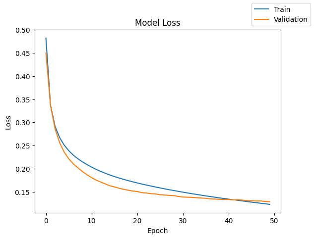

```python
# plot the loss
plot_metric(history1,'loss')
```

**Loss Graph Observations:**

#### Recall analysis

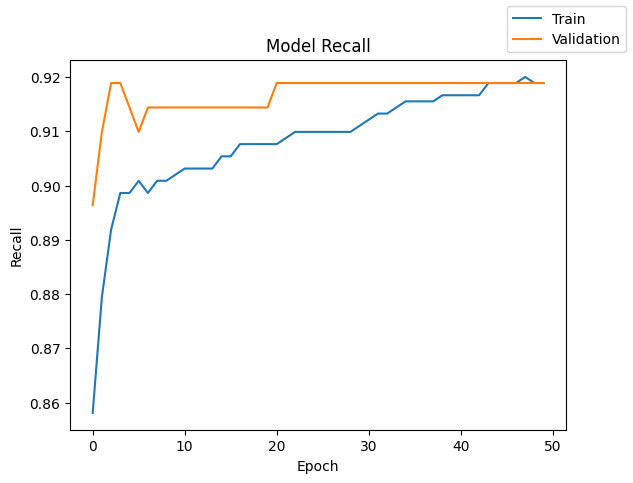

```python
# plot the recall
plot_metric(history1,'recall')
```

**Recall Graph Observations:**

- Training recall is improving from ~0.86 to ~0.92
- Validation recall shows slight erratic behavior with spikes early, plateauing just below 0.92 around epoch 20
- Validation recall is more unstable compared to relatively smooth training recall progression
- Both metrics are converging around final value range of 0.92

**Overall:**

- The loss convergence is 'Good' and fairly stable in training, but validation recall shows some instability during training process.

#### Confusion matrix analysis

```
500/500 ━━━━━━━━━━━━━━━━━━━━ 0s 183us/step
125/125 ━━━━━━━━━━━━━━━━━━━━ 0s 215us/step
```

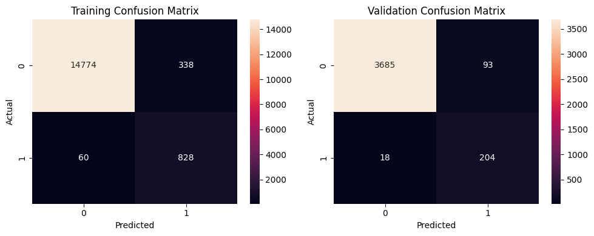

```python
# plot the confusion matrix for training, validation data
plot_confusion_matrices_v2(model1, X_train_normalized, y_train, X_val_normalized, y_val)
```

**Confusion matrix observations:**

- 18 False negatives from 222 total is resulting in a recall of 0.918919 on validation data
- The model is optimised for Recall hence, there are also 93 False Positives on validation data

### Model Results

```python
# Add model results to summary
results.loc[0] = ['Model 1',         #model name
    2,                              # hidden_layers
    [128, 64],                      # hidden_layer_neurons
    ["relu", "relu"],               # hidden_layers_activations
    50,                             # epochs
    64,                             # batch_size
    "SGD",                          # optimizer
    [0.01, "-"],                    # learning_rate, momentum
    "Xavier (aka Glorot)",          # kernel_weights_init
    "-",                            # regularization
    history1.history["loss"][-1],    # train_loss
    history1.history["val_loss"][-1],  # validation_loss
    history1.history["recall"][-1],    # train_recall
    history1.history["val_recall"][-1],# validation_recall
    round(end - start, 2)           # duration
]
results
```

|  | model_name | hidden_layers | hidden_layer_neurons | hidden_layer_activations | epochs | batch_size | optimizer | learning_rate, momentum | kernel_weights_init | regularization | train_loss | validation_loss | train_recall | validation_recall | duration |
| --- | --- | --- | --- | --- | --- | --- | --- | --- | --- | --- | --- | --- | --- | --- | --- |
| 0 | Model 1 | 2 | [128, 64] | [relu, relu] | 50 | 64 | SGD | [0.01, -] | Xavier (aka Glorot) | - | 0.122834 | 0.128425 | 0.918919 | 0.918919 | 6.2 |

### Summary

- Validation recall has fluctuations and is not smooth
- Still the recall is good at 0.91 with only 18 false negatives

### Next Steps

In next section following approaches will be explored to improve the model performance for recall further

1. Increasing the batch size
2. Adding more hidden layers
3. Reducing learning rate from 0.01 to 0.001
4. Adding momentum to 0.9
5. Switching the optimizer to Adam i.e., adaptive with momentum
6. Adding a dropout layer to regularize,
7. Batch Normalization
8. Batch Normalization with Dropout
9. Using 'He' for kernel weight initialisation
   - High false positive rate (93 in validation) indicates room for precision improvement and hence marginal inspection costs. With these techniques we will also explore improving the model accuracy to reduce false positives as well, if positive

# **4. Model Performance Improvement and Final Model Selection**

## Model 2 : Batch size '128'

```python
# clears the current Keras session, resets all layers, models previously created
tf.keras.backend.clear_session()
```

### Create Model

- The batch_size will be changed to 128 (from current 64).
- Rest of the configuration will remain the same

```python
# set batch size
batch_size = 128
```

```python
#Initializing the neural network
model2 = Sequential()
model2.add(Input(shape=(X_train_normalized.shape[1],)))

# add 2 hidden with 128, 64
model2.add(Dense(128,activation='relu'))
model2.add(Dense(64,activation='relu'))

# sigmoid output
model2.add(Dense(1,activation='sigmoid'))
print(model2.summary())

# defining SGD optimizer
optimizer = tf.keras.optimizers.SGD()

# compile with binary_crossentropy loss and SGD
model2.compile(loss='binary_crossentropy', optimizer=optimizer, metrics=['recall'])
```

```
Model: "sequential"
```

```
┏━━━━━━━━━━━━━━━━━━━━━━━━━━━━━━━━━┳━━━━━━━━━━━━━━━━━━━━━━━━┳━━━━━━━━━━━━━━━┓
┃ Layer (type)                    ┃ Output Shape           ┃       Param # ┃
┡━━━━━━━━━━━━━━━━━━━━━━━━━━━━━━━━━╇━━━━━━━━━━━━━━━━━━━━━━━━╇━━━━━━━━━━━━━━━┩
│ dense (Dense)                   │ (None, 128)            │         5,248 │
├─────────────────────────────────┼────────────────────────┼───────────────┤
│ dense_1 (Dense)                 │ (None, 64)             │         8,256 │
├─────────────────────────────────┼────────────────────────┼───────────────┤
│ dense_2 (Dense)                 │ (None, 1)              │            65 │
└─────────────────────────────────┴────────────────────────┴───────────────┘
```

```
 Total params: 13,569 (53.00 KB)
```

```
 Trainable params: 13,569 (53.00 KB)
```

```
 Non-trainable params: 0 (0.00 B)
```

```
None
```

### Training the model

```python
start = time.time()
history2 = model2.fit(X_train_normalized, y_train,
                    validation_data=(X_val_normalized, y_val) ,
                    batch_size=batch_size,
                    epochs=epochs,
                    class_weight=class_weight_dict)
end=time.time()

print("Time taken in seconds ",end-start)
```

```
125/125 ━━━━━━━━━━━━━━━━━━━━ 0s 1ms/step - loss: 0.5911 - recall: 0.5771 - val_loss: 0.5177 - val_recall: 0.8784
125/125 ━━━━━━━━━━━━━━━━━━━━ 0s 569us/step - loss: 0.4181 - recall: 0.8689 - val_loss: 0.4203 - val_recall: 0.8964
  1/125 ━━━━━━━━━━━━━━━━━━━━ 0s 6ms/step - loss: 0.2903 - recall: 1.0000
```

```
125/125 ━━━━━━━━━━━━━━━━━━━━ 0s 580us/step - loss: 0.3651 - recall: 0.8932 - val_loss: 0.3637 - val_recall: 0.9054
125/125 ━━━━━━━━━━━━━━━━━━━━ 0s 567us/step - loss: 0.3339 - recall: 0.8977 - val_loss: 0.3267 - val_recall: 0.9054
125/125 ━━━━━━━━━━━━━━━━━━━━ 0s 588us/step - loss: 0.3130 - recall: 0.9018 - val_loss: 0.3001 - val_recall: 0.9054
125/125 ━━━━━━━━━━━━━━━━━━━━ 0s 591us/step - loss: 0.2972 - recall: 0.9011 - val_loss: 0.2801 - val_recall: 0.9099
125/125 ━━━━━━━━━━━━━━━━━━━━ 0s 559us/step - loss: 0.2846 - recall: 0.8994 - val_loss: 0.2640 - val_recall: 0.9099
125/125 ━━━━━━━━━━━━━━━━━━━━ 0s 546us/step - loss: 0.2738 - recall: 0.9002 - val_loss: 0.2504 - val_recall: 0.9144
125/125 ━━━━━━━━━━━━━━━━━━━━ 0s 539us/step - loss: 0.2643 - recall: 0.9019 - val_loss: 0.2393 - val_recall: 0.9099
125/125 ━━━━━━━━━━━━━━━━━━━━ 0s 550us/step - loss: 0.2560 - recall: 0.9039 - val_loss: 0.2298 - val_recall: 0.9144
125/125 ━━━━━━━━━━━━━━━━━━━━ 0s 550us/step - loss: 0.2484 - recall: 0.9068 - val_loss: 0.2216 - val_recall: 0.9144
125/125 ━━━━━━━━━━━━━━━━━━━━ 0s 547us/step - loss: 0.2416 - recall: 0.9100 - val_loss: 0.2143 - val_recall: 0.9144
125/125 ━━━━━━━━━━━━━━━━━━━━ 0s 546us/step - loss: 0.2355 - recall: 0.9091 - val_loss: 0.2082 - val_recall: 0.9144
125/125 ━━━━━━━━━━━━━━━━━━━━ 0s 548us/step - loss: 0.2299 - recall: 0.9105 - val_loss: 0.2029 - val_recall: 0.9144
125/125 ━━━━━━━━━━━━━━━━━━━━ 0s 556us/step - loss: 0.2247 - recall: 0.9105 - val_loss: 0.1981 - val_recall: 0.9144
125/125 ━━━━━━━━━━━━━━━━━━━━ 0s 554us/step - loss: 0.2200 - recall: 0.9097 - val_loss: 0.1935 - val_recall: 0.9144
125/125 ━━━━━━━━━━━━━━━━━━━━ 0s 533us/step - loss: 0.2157 - recall: 0.9097 - val_loss: 0.1894 - val_recall: 0.9144
125/125 ━━━━━━━━━━━━━━━━━━━━ 0s 559us/step - loss: 0.2117 - recall: 0.9105 - val_loss: 0.1859 - val_recall: 0.9144
125/125 ━━━━━━━━━━━━━━━━━━━━ 0s 552us/step - loss: 0.2080 - recall: 0.9104 - val_loss: 0.1823 - val_recall: 0.9144
125/125 ━━━━━━━━━━━━━━━━━━━━ 0s 546us/step - loss: 0.2046 - recall: 0.9104 - val_loss: 0.1793 - val_recall: 0.9144
125/125 ━━━━━━━━━━━━━━━━━━━━ 0s 540us/step - loss: 0.2013 - recall: 0.9110 - val_loss: 0.1765 - val_recall: 0.9144
125/125 ━━━━━━━━━━━━━━━━━━━━ 0s 556us/step - loss: 0.1983 - recall: 0.9110 - val_loss: 0.1739 - val_recall: 0.9144
125/125 ━━━━━━━━━━━━━━━━━━━━ 0s 543us/step - loss: 0.1954 - recall: 0.9106 - val_loss: 0.1713 - val_recall: 0.9144
125/125 ━━━━━━━━━━━━━━━━━━━━ 0s 555us/step - loss: 0.1926 - recall: 0.9106 - val_loss: 0.1695 - val_recall: 0.9144
125/125 ━━━━━━━━━━━━━━━━━━━━ 0s 543us/step - loss: 0.1901 - recall: 0.9119 - val_loss: 0.1677 - val_recall: 0.9144
125/125 ━━━━━━━━━━━━━━━━━━━━ 0s 546us/step - loss: 0.1877 - recall: 0.9128 - val_loss: 0.1660 - val_recall: 0.9144
125/125 ━━━━━━━━━━━━━━━━━━━━ 0s 547us/step - loss: 0.1853 - recall: 0.9133 - val_loss: 0.1639 - val_recall: 0.9144
125/125 ━━━━━━━━━━━━━━━━━━━━ 0s 575us/step - loss: 0.1831 - recall: 0.9134 - val_loss: 0.1627 - val_recall: 0.9144
125/125 ━━━━━━━━━━━━━━━━━━━━ 0s 583us/step - loss: 0.1809 - recall: 0.9134 - val_loss: 0.1612 - val_recall: 0.9189
125/125 ━━━━━━━━━━━━━━━━━━━━ 0s 603us/step - loss: 0.1788 - recall: 0.9152 - val_loss: 0.1596 - val_recall: 0.9189
125/125 ━━━━━━━━━━━━━━━━━━━━ 0s 594us/step - loss: 0.1767 - recall: 0.9152 - val_loss: 0.1583 - val_recall: 0.9189
125/125 ━━━━━━━━━━━━━━━━━━━━ 0s 604us/step - loss: 0.1747 - recall: 0.9152 - val_loss: 0.1573 - val_recall: 0.9189
125/125 ━━━━━━━━━━━━━━━━━━━━ 0s 605us/step - loss: 0.1727 - recall: 0.9152 - val_loss: 0.1558 - val_recall: 0.9189
125/125 ━━━━━━━━━━━━━━━━━━━━ 0s 611us/step - loss: 0.1708 - recall: 0.9152 - val_loss: 0.1550 - val_recall: 0.9189
125/125 ━━━━━━━━━━━━━━━━━━━━ 0s 595us/step - loss: 0.1690 - recall: 0.9152 - val_loss: 0.1539 - val_recall: 0.9189
125/125 ━━━━━━━━━━━━━━━━━━━━ 0s 593us/step - loss: 0.1671 - recall: 0.9169 - val_loss: 0.1527 - val_recall: 0.9189
125/125 ━━━━━━━━━━━━━━━━━━━━ 0s 607us/step - loss: 0.1655 - recall: 0.9169 - val_loss: 0.1517 - val_recall: 0.9189
125/125 ━━━━━━━━━━━━━━━━━━━━ 0s 599us/step - loss: 0.1638 - recall: 0.9172 - val_loss: 0.1508 - val_recall: 0.9189
125/125 ━━━━━━━━━━━━━━━━━━━━ 0s 604us/step - loss: 0.1624 - recall: 0.9182 - val_loss: 0.1497 - val_recall: 0.9189
125/125 ━━━━━━━━━━━━━━━━━━━━ 0s 595us/step - loss: 0.1608 - recall: 0.9187 - val_loss: 0.1491 - val_recall: 0.9189
125/125 ━━━━━━━━━━━━━━━━━━━━ 0s 594us/step - loss: 0.1595 - recall: 0.9195 - val_loss: 0.1483 - val_recall: 0.9189
125/125 ━━━━━━━━━━━━━━━━━━━━ 0s 611us/step - loss: 0.1580 - recall: 0.9195 - val_loss: 0.1475 - val_recall: 0.9189
125/125 ━━━━━━━━━━━━━━━━━━━━ 0s 677us/step - loss: 0.1567 - recall: 0.9195 - val_loss: 0.1469 - val_recall: 0.9189
125/125 ━━━━━━━━━━━━━━━━━━━━ 0s 680us/step - loss: 0.1554 - recall: 0.9195 - val_loss: 0.1463 - val_recall: 0.9189
125/125 ━━━━━━━━━━━━━━━━━━━━ 0s 628us/step - loss: 0.1541 - recall: 0.9195 - val_loss: 0.1452 - val_recall: 0.9189
125/125 ━━━━━━━━━━━━━━━━━━━━ 0s 583us/step - loss: 0.1529 - recall: 0.9205 - val_loss: 0.1450 - val_recall: 0.9189
125/125 ━━━━━━━━━━━━━━━━━━━━ 0s 593us/step - loss: 0.1516 - recall: 0.9205 - val_loss: 0.1444 - val_recall: 0.9189
125/125 ━━━━━━━━━━━━━━━━━━━━ 0s 598us/step - loss: 0.1504 - recall: 0.9211 - val_loss: 0.1438 - val_recall: 0.9189
125/125 ━━━━━━━━━━━━━━━━━━━━ 0s 604us/step - loss: 0.1494 - recall: 0.9211 - val_loss: 0.1433 - val_recall: 0.9189
125/125 ━━━━━━━━━━━━━━━━━━━━ 0s 599us/step - loss: 0.1483 - recall: 0.9211 - val_loss: 0.1424 - val_recall: 0.9189
Time taken in seconds  4.191274881362915
```

### Model Analysis

#### Loss analysis

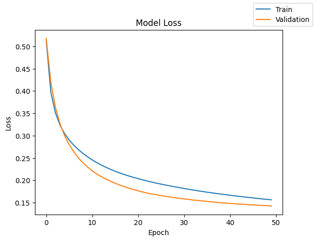

```python
plot_metric(history2,'loss')
```

**Loss Graph Observations:**

#### Recall analysis

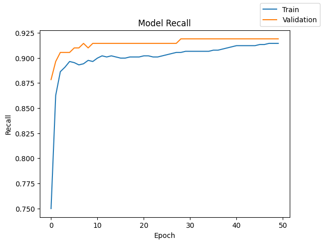

```python
plot_metric(history2,'recall')
```

**Recall Graph Observations:**

**Overall:**

#### Confusion matrix analysis

```
500/500 ━━━━━━━━━━━━━━━━━━━━ 0s 182us/step
125/125 ━━━━━━━━━━━━━━━━━━━━ 0s 221us/step
```

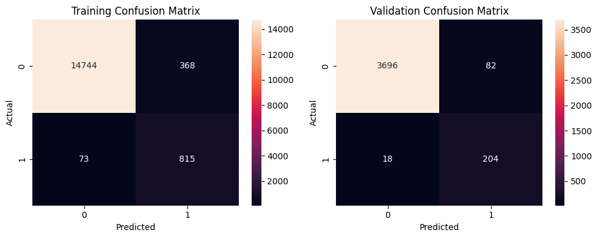

```python
# plot the confusion matrix for train and validation data
plot_confusion_matrices_v2(model2, X_train_normalized, y_train, X_val_normalized, y_val)
```

**Confusion matrix observations**

- False negatives are the same value of 18 for validation
- False positives have decreased to 82 from 93

### Model Results

```python
# Add model results to summary
results.loc[1] = ['Model 2',
    2,                              # hidden_layers
    [128, 64],                      # neurons_in_hidden_layers
    ["relu", "relu"],              # activation_function_in__hidden_layer
    50,                             # epochs
    128,                             # batch_size
    "SGD",                          # optimizer
    [0.01, "-"],                    # learning_rate, momentum
    "Xavier (aka Glorot)",          # kernel_weights_init
    "-",                            # regularization
    history2.history["loss"][-1],   # train_loss
    history2.history["val_loss"][-1],  # validation_loss
    history2.history["recall"][-1],    # train_recall
    history2.history["val_recall"][-1],# validation_recall
    round(end - start, 2)           # duration
]
results
```

|  | model_name | hidden_layers | hidden_layer_neurons | hidden_layer_activations | epochs | batch_size | optimizer | learning_rate, momentum | kernel_weights_init | regularization | train_loss | validation_loss | train_recall | validation_recall | duration |
| --- | --- | --- | --- | --- | --- | --- | --- | --- | --- | --- | --- | --- | --- | --- | --- |
| 0 | Model 1 | 2 | [128, 64] | [relu, relu] | 50 | 64 | SGD | [0.01, -] | Xavier (aka Glorot) | - | 0.122834 | 0.128425 | 0.918919 | 0.918919 | 6.20 |
| 1 | Model 2 | 2 | [128, 64] | [relu, relu] | 50 | 128 | SGD | [0.01, -] | Xavier (aka Glorot) | - | 0.156367 | 0.142436 | 0.914414 | 0.918919 | 4.19 |

### Summary

- Increasing the batch_size from 64 to 128 has not improved the validation_recall
- It has also increase the validation loss
- Training duration has reduced from ~6 seconds to ~4 seconds as batch size increased

## Model 3 : Another Hidden layer

```python
# clears the current Keras session, resets all layers, models previously created
tf.keras.backend.clear_session()
```

### Create Model

```python
# set batch size back to 64
batch_size = 64
```

```python
#Initializing the neural network
model3 = Sequential()
model3.add(Input(shape=(X_train_normalized.shape[1],)))

# add another hidden with 256 neurons
model3.add(Dense(256,activation='relu'))
model3.add(Dense(128,activation='relu'))
model3.add(Dense(64,activation='relu'))

# sigmoid output
model3.add(Dense(1,activation='sigmoid'))
print(model3.summary())

# defining SGD optimizer
optimizer = tf.keras.optimizers.SGD()

# compile with binary_crossentropy loss and SGD
model3.compile(loss='binary_crossentropy', optimizer=optimizer, metrics=['recall'])
```

```
Model: "sequential"
```

```
┏━━━━━━━━━━━━━━━━━━━━━━━━━━━━━━━━━┳━━━━━━━━━━━━━━━━━━━━━━━━┳━━━━━━━━━━━━━━━┓
┃ Layer (type)                    ┃ Output Shape           ┃       Param # ┃
┡━━━━━━━━━━━━━━━━━━━━━━━━━━━━━━━━━╇━━━━━━━━━━━━━━━━━━━━━━━━╇━━━━━━━━━━━━━━━┩
│ dense (Dense)                   │ (None, 256)            │        10,496 │
├─────────────────────────────────┼────────────────────────┼───────────────┤
│ dense_1 (Dense)                 │ (None, 128)            │        32,896 │
├─────────────────────────────────┼────────────────────────┼───────────────┤
│ dense_2 (Dense)                 │ (None, 64)             │         8,256 │
├─────────────────────────────────┼────────────────────────┼───────────────┤
│ dense_3 (Dense)                 │ (None, 1)              │            65 │
└─────────────────────────────────┴────────────────────────┴───────────────┘
```

```
 Total params: 51,713 (202.00 KB)
```

```
 Trainable params: 51,713 (202.00 KB)
```

```
 Non-trainable params: 0 (0.00 B)
```

```
None
```

### Training the model

```python
# fit the model and capture start, end times
start = time.time()
history3 = model3.fit(X_train_normalized, y_train,
                    validation_data=(X_val_normalized, y_val) ,
                    batch_size=batch_size,
                    epochs=epochs,
                    class_weight=class_weight_dict)
end=time.time()

print("Time taken in seconds ",end-start)
```

```
250/250 ━━━━━━━━━━━━━━━━━━━━ 0s 953us/step - loss: 0.5554 - recall: 0.8396 - val_loss: 0.4290 - val_recall: 0.9099
207/250 ━━━━━━━━━━━━━━━━━━━━ 0s 487us/step - loss: 0.3386 - recall: 0.8814
```

```
250/250 ━━━━━━━━━━━━━━━━━━━━ 0s 652us/step - loss: 0.3347 - recall: 0.8812 - val_loss: 0.3055 - val_recall: 0.9189
250/250 ━━━━━━━━━━━━━━━━━━━━ 0s 644us/step - loss: 0.2774 - recall: 0.8918 - val_loss: 0.2571 - val_recall: 0.9189
250/250 ━━━━━━━━━━━━━━━━━━━━ 0s 636us/step - loss: 0.2487 - recall: 0.8943 - val_loss: 0.2298 - val_recall: 0.9144
250/250 ━━━━━━━━━━━━━━━━━━━━ 0s 638us/step - loss: 0.2291 - recall: 0.9021 - val_loss: 0.2112 - val_recall: 0.9144
250/250 ━━━━━━━━━━━━━━━━━━━━ 0s 644us/step - loss: 0.2144 - recall: 0.9043 - val_loss: 0.1970 - val_recall: 0.9144
250/250 ━━━━━━━━━━━━━━━━━━━━ 0s 650us/step - loss: 0.2028 - recall: 0.9050 - val_loss: 0.1870 - val_recall: 0.9144
250/250 ━━━━━━━━━━━━━━━━━━━━ 0s 659us/step - loss: 0.1929 - recall: 0.9075 - val_loss: 0.1797 - val_recall: 0.9189
250/250 ━━━━━━━━━━━━━━━━━━━━ 0s 638us/step - loss: 0.1844 - recall: 0.9119 - val_loss: 0.1725 - val_recall: 0.9189
250/250 ━━━━━━━━━━━━━━━━━━━━ 0s 622us/step - loss: 0.1771 - recall: 0.9117 - val_loss: 0.1675 - val_recall: 0.9189
250/250 ━━━━━━━━━━━━━━━━━━━━ 0s 630us/step - loss: 0.1707 - recall: 0.9134 - val_loss: 0.1628 - val_recall: 0.9189
250/250 ━━━━━━━━━━━━━━━━━━━━ 0s 629us/step - loss: 0.1650 - recall: 0.9131 - val_loss: 0.1594 - val_recall: 0.9189
250/250 ━━━━━━━━━━━━━━━━━━━━ 0s 634us/step - loss: 0.1597 - recall: 0.9144 - val_loss: 0.1564 - val_recall: 0.9189
250/250 ━━━━━━━━━━━━━━━━━━━━ 0s 632us/step - loss: 0.1549 - recall: 0.9162 - val_loss: 0.1548 - val_recall: 0.9189
250/250 ━━━━━━━━━━━━━━━━━━━━ 0s 643us/step - loss: 0.1507 - recall: 0.9168 - val_loss: 0.1528 - val_recall: 0.9189
250/250 ━━━━━━━━━━━━━━━━━━━━ 0s 633us/step - loss: 0.1467 - recall: 0.9171 - val_loss: 0.1517 - val_recall: 0.9189
250/250 ━━━━━━━━━━━━━━━━━━━━ 0s 635us/step - loss: 0.1431 - recall: 0.9171 - val_loss: 0.1502 - val_recall: 0.9189
250/250 ━━━━━━━━━━━━━━━━━━━━ 0s 651us/step - loss: 0.1397 - recall: 0.9181 - val_loss: 0.1490 - val_recall: 0.9189
250/250 ━━━━━━━━━━━━━━━━━━━━ 0s 655us/step - loss: 0.1365 - recall: 0.9181 - val_loss: 0.1484 - val_recall: 0.9189
250/250 ━━━━━━━━━━━━━━━━━━━━ 0s 640us/step - loss: 0.1334 - recall: 0.9189 - val_loss: 0.1459 - val_recall: 0.9189
250/250 ━━━━━━━━━━━━━━━━━━━━ 0s 641us/step - loss: 0.1305 - recall: 0.9189 - val_loss: 0.1461 - val_recall: 0.9189
250/250 ━━━━━━━━━━━━━━━━━━━━ 0s 614us/step - loss: 0.1280 - recall: 0.9195 - val_loss: 0.1445 - val_recall: 0.9189
250/250 ━━━━━━━━━━━━━━━━━━━━ 0s 609us/step - loss: 0.1252 - recall: 0.9219 - val_loss: 0.1436 - val_recall: 0.9189
250/250 ━━━━━━━━━━━━━━━━━━━━ 0s 608us/step - loss: 0.1228 - recall: 0.9219 - val_loss: 0.1429 - val_recall: 0.9189
250/250 ━━━━━━━━━━━━━━━━━━━━ 0s 600us/step - loss: 0.1205 - recall: 0.9226 - val_loss: 0.1405 - val_recall: 0.9189
250/250 ━━━━━━━━━━━━━━━━━━━━ 0s 590us/step - loss: 0.1180 - recall: 0.9226 - val_loss: 0.1409 - val_recall: 0.9189
250/250 ━━━━━━━━━━━━━━━━━━━━ 0s 601us/step - loss: 0.1157 - recall: 0.9227 - val_loss: 0.1385 - val_recall: 0.9189
250/250 ━━━━━━━━━━━━━━━━━━━━ 0s 633us/step - loss: 0.1136 - recall: 0.9229 - val_loss: 0.1385 - val_recall: 0.9189
250/250 ━━━━━━━━━━━━━━━━━━━━ 0s 622us/step - loss: 0.1115 - recall: 0.9231 - val_loss: 0.1376 - val_recall: 0.9189
250/250 ━━━━━━━━━━━━━━━━━━━━ 0s 608us/step - loss: 0.1091 - recall: 0.9245 - val_loss: 0.1363 - val_recall: 0.9189
250/250 ━━━━━━━━━━━━━━━━━━━━ 0s 612us/step - loss: 0.1070 - recall: 0.9245 - val_loss: 0.1347 - val_recall: 0.9189
250/250 ━━━━━━━━━━━━━━━━━━━━ 0s 601us/step - loss: 0.1046 - recall: 0.9245 - val_loss: 0.1333 - val_recall: 0.9189
250/250 ━━━━━━━━━━━━━━━━━━━━ 0s 605us/step - loss: 0.1027 - recall: 0.9257 - val_loss: 0.1336 - val_recall: 0.9189
250/250 ━━━━━━━━━━━━━━━━━━━━ 0s 608us/step - loss: 0.1006 - recall: 0.9271 - val_loss: 0.1332 - val_recall: 0.9189
250/250 ━━━━━━━━━━━━━━━━━━━━ 0s 606us/step - loss: 0.0986 - recall: 0.9260 - val_loss: 0.1319 - val_recall: 0.9189
250/250 ━━━━━━━━━━━━━━━━━━━━ 0s 602us/step - loss: 0.0965 - recall: 0.9295 - val_loss: 0.1299 - val_recall: 0.9189
250/250 ━━━━━━━━━━━━━━━━━━━━ 0s 604us/step - loss: 0.0947 - recall: 0.9314 - val_loss: 0.1303 - val_recall: 0.9189
250/250 ━━━━━━━━━━━━━━━━━━━━ 0s 622us/step - loss: 0.0927 - recall: 0.9352 - val_loss: 0.1298 - val_recall: 0.9189
250/250 ━━━━━━━━━━━━━━━━━━━━ 0s 613us/step - loss: 0.0907 - recall: 0.9362 - val_loss: 0.1278 - val_recall: 0.9189
250/250 ━━━━━━━━━━━━━━━━━━━━ 0s 612us/step - loss: 0.0888 - recall: 0.9364 - val_loss: 0.1245 - val_recall: 0.9189
250/250 ━━━━━━━━━━━━━━━━━━━━ 0s 608us/step - loss: 0.0870 - recall: 0.9364 - val_loss: 0.1248 - val_recall: 0.9189
250/250 ━━━━━━━━━━━━━━━━━━━━ 0s 603us/step - loss: 0.0853 - recall: 0.9364 - val_loss: 0.1209 - val_recall: 0.9189
250/250 ━━━━━━━━━━━━━━━━━━━━ 0s 606us/step - loss: 0.0829 - recall: 0.9364 - val_loss: 0.1212 - val_recall: 0.9189
250/250 ━━━━━━━━━━━━━━━━━━━━ 0s 602us/step - loss: 0.0809 - recall: 0.9373 - val_loss: 0.1205 - val_recall: 0.9189
250/250 ━━━━━━━━━━━━━━━━━━━━ 0s 603us/step - loss: 0.0791 - recall: 0.9396 - val_loss: 0.1187 - val_recall: 0.9189
250/250 ━━━━━━━━━━━━━━━━━━━━ 0s 605us/step - loss: 0.0774 - recall: 0.9407 - val_loss: 0.1175 - val_recall: 0.9189
250/250 ━━━━━━━━━━━━━━━━━━━━ 0s 606us/step - loss: 0.0758 - recall: 0.9428 - val_loss: 0.1158 - val_recall: 0.9189
250/250 ━━━━━━━━━━━━━━━━━━━━ 0s 606us/step - loss: 0.0737 - recall: 0.9446 - val_loss: 0.1140 - val_recall: 0.9189
250/250 ━━━━━━━━━━━━━━━━━━━━ 0s 612us/step - loss: 0.0721 - recall: 0.9446 - val_loss: 0.1142 - val_recall: 0.9189
250/250 ━━━━━━━━━━━━━━━━━━━━ 0s 606us/step - loss: 0.0703 - recall: 0.9477 - val_loss: 0.1127 - val_recall: 0.9189
Time taken in seconds  8.363917112350464
```

### Model Analysis

#### Loss analysis

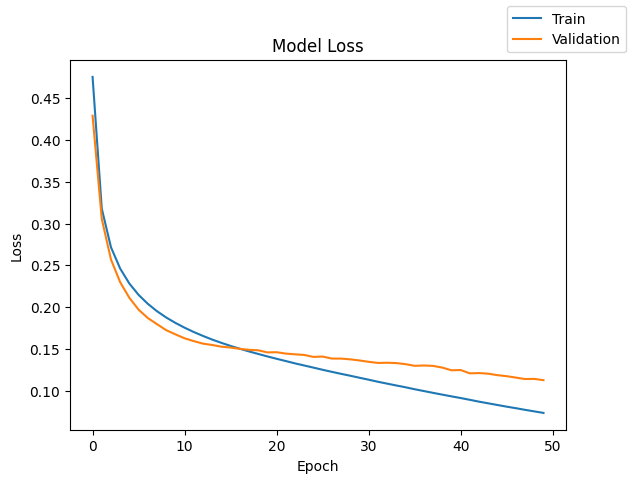

```python
# plot the loss
plot_metric(history3,'loss')
```

**Loss Graph Observations:**

- Training loss decreases from ~0.47 to ~0.08, validation loss from ~0.45 to ~0.12
- Slight gap between training and validation loss indicating mild overfitting
- Smooth convergence with no oscillations

#### Recall analysis

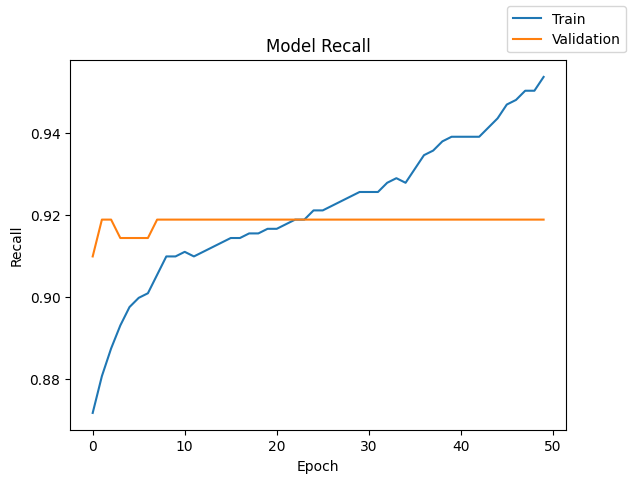

```python
# plot the recall
plot_metric(history3,'recall')
```

**Recall Graph Observations:**

- Training recall improves continuously from ~0.87 to ~0.95 over 50 epochs
- Validation recall plateaus at ~0.92 (flat line throughout training)
- Significant 3% gap between training and validation recall showing overfitting

#### Confusion matrix analysis

```
500/500 ━━━━━━━━━━━━━━━━━━━━ 0s 219us/step
125/125 ━━━━━━━━━━━━━━━━━━━━ 0s 232us/step
```

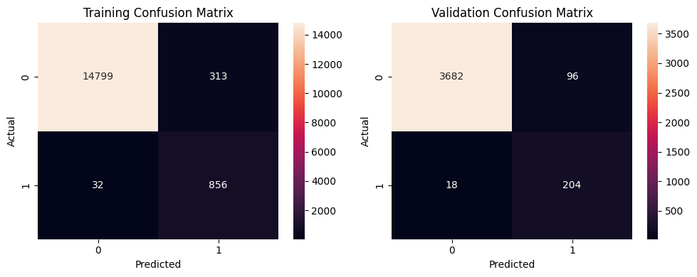

```python
# plot the confusion matrix for train and validation data
plot_confusion_matrices_v2(model3, X_train_normalized, y_train, X_val_normalized, y_val)
```

**Confusion matrix observations**

- False negatives are again back at 18
- False positives are at 96
- These are similar to the initial model with 2 layers and batch size 64

### Model Results

```python
# Add model results to summary
results.loc[2] = ['Model 3',
    3,                              # hidden_layers
    [256,128, 64],                      # neurons_in_hidden_layers
    ["relu", "relu", "relu"],              # activation_function_in__hidden_layer
    50,                             # epochs
    64,                             # batch_size
    "SGD",                          # optimizer
    [0.01, "-"],                    # learning_rate, momentum
    "Xavier (aka Glorot)",          # kernel_weights_init
    "-",                            # regularization
    history3.history["loss"][-1],   # train_loss
    history3.history["val_loss"][-1],  # validation_loss
    history3.history["recall"][-1],    # train_recall
    history3.history["val_recall"][-1],# validation_recall
    round(end - start, 2)           # duration
]
results
```

|  | model_name | hidden_layers | hidden_layer_neurons | hidden_layer_activations | epochs | batch_size | optimizer | learning_rate, momentum | kernel_weights_init | regularization | train_loss | validation_loss | train_recall | validation_recall | duration |
| --- | --- | --- | --- | --- | --- | --- | --- | --- | --- | --- | --- | --- | --- | --- | --- |
| 0 | Model 1 | 2 | [128, 64] | [relu, relu] | 50 | 64 | SGD | [0.01, -] | Xavier (aka Glorot) | - | 0.122834 | 0.128425 | 0.918919 | 0.918919 | 6.20 |
| 1 | Model 2 | 2 | [128, 64] | [relu, relu] | 50 | 128 | SGD | [0.01, -] | Xavier (aka Glorot) | - | 0.156367 | 0.142436 | 0.914414 | 0.918919 | 4.19 |
| 2 | Model 3 | 3 | [256, 128, 64] | [relu, relu, relu] | 50 | 64 | SGD | [0.01, -] | Xavier (aka Glorot) | - | 0.073536 | 0.112700 | 0.953829 | 0.918919 | 8.36 |

## Model 4: learning rate '0.001', SGD

```python
# clears the current Keras session, resets all layers, models previously created
tf.keras.backend.clear_session()
```

### Create Model

- Learning rate for SGD will be reduced to 0.001 from default 0.01
- Rest of the configuration will remain the same

```python
#Initializing the neural network
model4 = Sequential()
model4.add(Input(shape=(X_train_normalized.shape[1],)))

# add 3 hidden layers with 256, 128, 64
model4.add(Dense(256,activation='relu'))
model4.add(Dense(128,activation='relu'))
model4.add(Dense(64,activation='relu'))

# sigmoid output
model4.add(Dense(1,activation='sigmoid'))
print(model4.summary())

# defining SGD optimizer
learning_rate = 0.001
optimizer = tf.keras.optimizers.SGD(learning_rate=learning_rate)

# compile with binary_crossentropy loss and SGD
model4.compile(loss='binary_crossentropy', optimizer=optimizer, metrics=['recall'])
```

```
Model: "sequential"
```

```
┏━━━━━━━━━━━━━━━━━━━━━━━━━━━━━━━━━┳━━━━━━━━━━━━━━━━━━━━━━━━┳━━━━━━━━━━━━━━━┓
┃ Layer (type)                    ┃ Output Shape           ┃       Param # ┃
┡━━━━━━━━━━━━━━━━━━━━━━━━━━━━━━━━━╇━━━━━━━━━━━━━━━━━━━━━━━━╇━━━━━━━━━━━━━━━┩
│ dense (Dense)                   │ (None, 256)            │        10,496 │
├─────────────────────────────────┼────────────────────────┼───────────────┤
│ dense_1 (Dense)                 │ (None, 128)            │        32,896 │
├─────────────────────────────────┼────────────────────────┼───────────────┤
│ dense_2 (Dense)                 │ (None, 64)             │         8,256 │
├─────────────────────────────────┼────────────────────────┼───────────────┤
│ dense_3 (Dense)                 │ (None, 1)              │            65 │
└─────────────────────────────────┴────────────────────────┴───────────────┘
```

```
 Total params: 51,713 (202.00 KB)
```

```
 Trainable params: 51,713 (202.00 KB)
```

```
 Non-trainable params: 0 (0.00 B)
```

```
None
```

### Training the model

```python
# fit the model and capture start, end times
start = time.time()
history4 = model4.fit(X_train_normalized, y_train,
                    validation_data=(X_val_normalized, y_val) ,
                    batch_size=batch_size,
                    epochs=epochs,
                    class_weight=class_weight_dict)
end=time.time()

print("Time taken in seconds ",end-start)
```

```
250/250 ━━━━━━━━━━━━━━━━━━━━ 0s 956us/step - loss: 0.6879 - recall: 0.2213 - val_loss: 0.6326 - val_recall: 0.8423
197/250 ━━━━━━━━━━━━━━━━━━━━ 0s 512us/step - loss: 0.5766 - recall: 0.8298
```

```
250/250 ━━━━━━━━━━━━━━━━━━━━ 0s 675us/step - loss: 0.5728 - recall: 0.8378 - val_loss: 0.6234 - val_recall: 0.9189
250/250 ━━━━━━━━━━━━━━━━━━━━ 0s 646us/step - loss: 0.5193 - recall: 0.8771 - val_loss: 0.5845 - val_recall: 0.9099
250/250 ━━━━━━━━━━━━━━━━━━━━ 0s 659us/step - loss: 0.4786 - recall: 0.8791 - val_loss: 0.5384 - val_recall: 0.9054
250/250 ━━━━━━━━━━━━━━━━━━━━ 0s 639us/step - loss: 0.4447 - recall: 0.8737 - val_loss: 0.4951 - val_recall: 0.8919
250/250 ━━━━━━━━━━━━━━━━━━━━ 0s 653us/step - loss: 0.4164 - recall: 0.8710 - val_loss: 0.4571 - val_recall: 0.8919
250/250 ━━━━━━━━━━━━━━━━━━━━ 0s 627us/step - loss: 0.3927 - recall: 0.8723 - val_loss: 0.4244 - val_recall: 0.9009
250/250 ━━━━━━━━━━━━━━━━━━━━ 0s 674us/step - loss: 0.3728 - recall: 0.8761 - val_loss: 0.3970 - val_recall: 0.9009
250/250 ━━━━━━━━━━━━━━━━━━━━ 0s 653us/step - loss: 0.3559 - recall: 0.8823 - val_loss: 0.3736 - val_recall: 0.9054
250/250 ━━━━━━━━━━━━━━━━━━━━ 0s 639us/step - loss: 0.3417 - recall: 0.8810 - val_loss: 0.3538 - val_recall: 0.9144
250/250 ━━━━━━━━━━━━━━━━━━━━ 0s 635us/step - loss: 0.3296 - recall: 0.8861 - val_loss: 0.3370 - val_recall: 0.9144
250/250 ━━━━━━━━━━━━━━━━━━━━ 0s 641us/step - loss: 0.3191 - recall: 0.8883 - val_loss: 0.3222 - val_recall: 0.9189
250/250 ━━━━━━━━━━━━━━━━━━━━ 0s 640us/step - loss: 0.3100 - recall: 0.8912 - val_loss: 0.3093 - val_recall: 0.9189
250/250 ━━━━━━━━━━━━━━━━━━━━ 0s 640us/step - loss: 0.3021 - recall: 0.8919 - val_loss: 0.2979 - val_recall: 0.9189
250/250 ━━━━━━━━━━━━━━━━━━━━ 0s 635us/step - loss: 0.2950 - recall: 0.8961 - val_loss: 0.2880 - val_recall: 0.9189
250/250 ━━━━━━━━━━━━━━━━━━━━ 0s 653us/step - loss: 0.2888 - recall: 0.8977 - val_loss: 0.2790 - val_recall: 0.9189
250/250 ━━━━━━━━━━━━━━━━━━━━ 0s 654us/step - loss: 0.2831 - recall: 0.8987 - val_loss: 0.2708 - val_recall: 0.9189
250/250 ━━━━━━━━━━━━━━━━━━━━ 0s 649us/step - loss: 0.2780 - recall: 0.8992 - val_loss: 0.2635 - val_recall: 0.9234
250/250 ━━━━━━━━━━━━━━━━━━━━ 0s 663us/step - loss: 0.2732 - recall: 0.9008 - val_loss: 0.2570 - val_recall: 0.9189
250/250 ━━━━━━━━━━━━━━━━━━━━ 0s 650us/step - loss: 0.2688 - recall: 0.9005 - val_loss: 0.2512 - val_recall: 0.9189
250/250 ━━━━━━━━━━━━━━━━━━━━ 0s 624us/step - loss: 0.2647 - recall: 0.9042 - val_loss: 0.2456 - val_recall: 0.9189
250/250 ━━━━━━━━━━━━━━━━━━━━ 0s 656us/step - loss: 0.2609 - recall: 0.9028 - val_loss: 0.2404 - val_recall: 0.9144
250/250 ━━━━━━━━━━━━━━━━━━━━ 0s 629us/step - loss: 0.2573 - recall: 0.9032 - val_loss: 0.2356 - val_recall: 0.9144
250/250 ━━━━━━━━━━━━━━━━━━━━ 0s 620us/step - loss: 0.2538 - recall: 0.9043 - val_loss: 0.2311 - val_recall: 0.9144
250/250 ━━━━━━━━━━━━━━━━━━━━ 0s 599us/step - loss: 0.2506 - recall: 0.9056 - val_loss: 0.2267 - val_recall: 0.9144
250/250 ━━━━━━━━━━━━━━━━━━━━ 0s 598us/step - loss: 0.2475 - recall: 0.9056 - val_loss: 0.2228 - val_recall: 0.9144
250/250 ━━━━━━━━━━━━━━━━━━━━ 0s 603us/step - loss: 0.2445 - recall: 0.9063 - val_loss: 0.2190 - val_recall: 0.9144
250/250 ━━━━━━━━━━━━━━━━━━━━ 0s 639us/step - loss: 0.2417 - recall: 0.9065 - val_loss: 0.2155 - val_recall: 0.9144
250/250 ━━━━━━━━━━━━━━━━━━━━ 0s 666us/step - loss: 0.2390 - recall: 0.9072 - val_loss: 0.2121 - val_recall: 0.9144
250/250 ━━━━━━━━━━━━━━━━━━━━ 0s 625us/step - loss: 0.2364 - recall: 0.9078 - val_loss: 0.2090 - val_recall: 0.9144
250/250 ━━━━━━━━━━━━━━━━━━━━ 0s 615us/step - loss: 0.2340 - recall: 0.9078 - val_loss: 0.2059 - val_recall: 0.9144
250/250 ━━━━━━━━━━━━━━━━━━━━ 0s 601us/step - loss: 0.2316 - recall: 0.9078 - val_loss: 0.2032 - val_recall: 0.9144
250/250 ━━━━━━━━━━━━━━━━━━━━ 0s 608us/step - loss: 0.2294 - recall: 0.9078 - val_loss: 0.2005 - val_recall: 0.9144
250/250 ━━━━━━━━━━━━━━━━━━━━ 0s 616us/step - loss: 0.2272 - recall: 0.9083 - val_loss: 0.1982 - val_recall: 0.9144
250/250 ━━━━━━━━━━━━━━━━━━━━ 0s 661us/step - loss: 0.2251 - recall: 0.9083 - val_loss: 0.1958 - val_recall: 0.9144
250/250 ━━━━━━━━━━━━━━━━━━━━ 0s 646us/step - loss: 0.2231 - recall: 0.9088 - val_loss: 0.1936 - val_recall: 0.9144
250/250 ━━━━━━━━━━━━━━━━━━━━ 0s 643us/step - loss: 0.2211 - recall: 0.9088 - val_loss: 0.1914 - val_recall: 0.9144
250/250 ━━━━━━━━━━━━━━━━━━━━ 0s 648us/step - loss: 0.2192 - recall: 0.9102 - val_loss: 0.1893 - val_recall: 0.9144
250/250 ━━━━━━━━━━━━━━━━━━━━ 0s 643us/step - loss: 0.2174 - recall: 0.9106 - val_loss: 0.1873 - val_recall: 0.9144
250/250 ━━━━━━━━━━━━━━━━━━━━ 0s 656us/step - loss: 0.2156 - recall: 0.9106 - val_loss: 0.1854 - val_recall: 0.9144
250/250 ━━━━━━━━━━━━━━━━━━━━ 0s 642us/step - loss: 0.2139 - recall: 0.9106 - val_loss: 0.1835 - val_recall: 0.9144
250/250 ━━━━━━━━━━━━━━━━━━━━ 0s 661us/step - loss: 0.2122 - recall: 0.9098 - val_loss: 0.1818 - val_recall: 0.9144
250/250 ━━━━━━━━━━━━━━━━━━━━ 0s 646us/step - loss: 0.2105 - recall: 0.9096 - val_loss: 0.1802 - val_recall: 0.9144
250/250 ━━━━━━━━━━━━━━━━━━━━ 0s 653us/step - loss: 0.2089 - recall: 0.9096 - val_loss: 0.1787 - val_recall: 0.9144
250/250 ━━━━━━━━━━━━━━━━━━━━ 0s 653us/step - loss: 0.2074 - recall: 0.9096 - val_loss: 0.1771 - val_recall: 0.9144
250/250 ━━━━━━━━━━━━━━━━━━━━ 0s 646us/step - loss: 0.2059 - recall: 0.9096 - val_loss: 0.1756 - val_recall: 0.9144
250/250 ━━━━━━━━━━━━━━━━━━━━ 0s 637us/step - loss: 0.2044 - recall: 0.9110 - val_loss: 0.1741 - val_recall: 0.9144
250/250 ━━━━━━━━━━━━━━━━━━━━ 0s 644us/step - loss: 0.2030 - recall: 0.9110 - val_loss: 0.1728 - val_recall: 0.9144
250/250 ━━━━━━━━━━━━━━━━━━━━ 0s 650us/step - loss: 0.2016 - recall: 0.9110 - val_loss: 0.1714 - val_recall: 0.9144
250/250 ━━━━━━━━━━━━━━━━━━━━ 0s 641us/step - loss: 0.2003 - recall: 0.9110 - val_loss: 0.1702 - val_recall: 0.9144
Time taken in seconds  8.620022058486938
```

### Model Analysis

#### Loss analysis

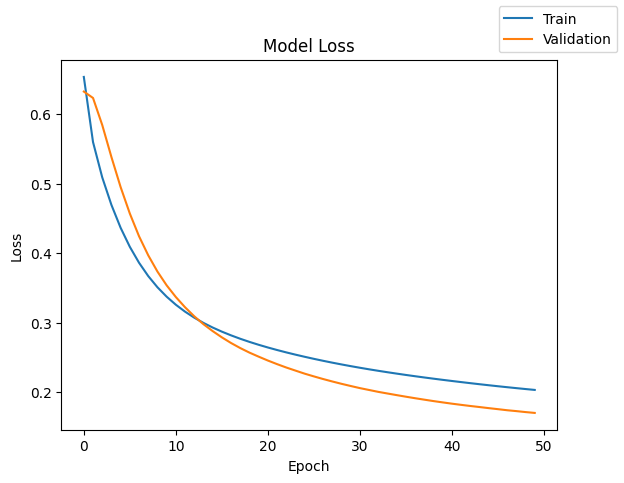

```python
# plot the loss
plot_metric(history4,'loss')
```

**Loss Graph Observations:**

- Training loss decreases from ~0.65 to just above ~0.20, validation loss from ~0.65 to below ~0.20
- There is close convergence between training and validation loss curves
- Smooth, steady decline

#### Recall analysis

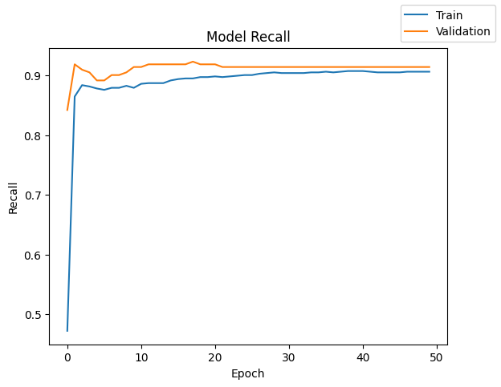

```python
# plot the recall
plot_metric(history4,'recall')
```

**Recall Graph Observations:**

- Training recall plateaus at ~0.90 after initial jump from ~0.47
- Validation recall stabilizes at ~0.91 (slightly higher than training)
- Good generalization with validation recall consistently matching/exceeding training

#### Confusion matrix analysis

```
500/500 ━━━━━━━━━━━━━━━━━━━━ 0s 221us/step
125/125 ━━━━━━━━━━━━━━━━━━━━ 0s 250us/step
```

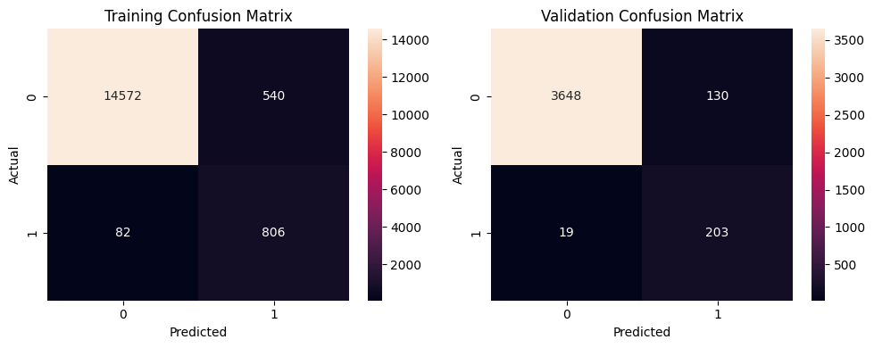

```python
# plot the confusion matrix for train and validation data
plot_confusion_matrices_v2(model4, X_train_normalized, y_train, X_val_normalized, y_val)
```

**Confusion matrix observations**

- False negatives have increased to 19 from 18
- False positives have increased to 130
- But the model's overall generalisation is better compared to the previous ones

**Confusion matrix observations**

### Model Results

```python
# Add model results to summary
results.loc[3] = ['Model 4',
    3,                              # hidden_layers
    [256, 128, 64],                 # neurons_in_hidden_layers
    ["relu", "relu", "relu"],       # activation_function_in__hidden_layer
    50,                             # epochs
    64,                             # batch_size
    "SGD",                          # optimizer
    [0.001, "-"],                    # learning_rate, momentum
    "Xavier (aka Glorot)",          # kernel_weights_init
    "-",                            # regularization
    history4.history["loss"][-1],   # train_loss
    history4.history["val_loss"][-1],  # validation_loss
    history4.history["recall"][-1],    # train_recall
    history4.history["val_recall"][-1],# validation_recall
    round(end - start, 2)           # duration
]
results
```

|  | model_name | hidden_layers | hidden_layer_neurons | hidden_layer_activations | epochs | batch_size | optimizer | learning_rate, momentum | kernel_weights_init | regularization | train_loss | validation_loss | train_recall | validation_recall | duration |
| --- | --- | --- | --- | --- | --- | --- | --- | --- | --- | --- | --- | --- | --- | --- | --- |
| 0 | Model 1 | 2 | [128, 64] | [relu, relu] | 50 | 64 | SGD | [0.01, -] | Xavier (aka Glorot) | - | 0.122834 | 0.128425 | 0.918919 | 0.918919 | 6.20 |
| 1 | Model 2 | 2 | [128, 64] | [relu, relu] | 50 | 128 | SGD | [0.01, -] | Xavier (aka Glorot) | - | 0.156367 | 0.142436 | 0.914414 | 0.918919 | 4.19 |
| 2 | Model 3 | 3 | [256, 128, 64] | [relu, relu, relu] | 50 | 64 | SGD | [0.01, -] | Xavier (aka Glorot) | - | 0.073536 | 0.112700 | 0.953829 | 0.918919 | 8.36 |
| 3 | Model 4 | 3 | [256, 128, 64] | [relu, relu, relu] | 50 | 64 | SGD | [0.001, -] | Xavier (aka Glorot) | - | 0.203309 | 0.170217 | 0.906532 | 0.914414 | 8.62 |

### Summary

- Achieves best generalization with validation recall (0.914) exceeding training recall (0.907)
- Eliminates overfitting as validation metrics are better than training metrics
- Balanced performance across loss and recall with no train-validation gaps
- Model training duration has increased to ~9 seconds from ~6 seconds (for model 1)

## Model 5: momentum '0.9', SGD

```python
# clears the current Keras session, resets all layers, models previously created
tf.keras.backend.clear_session()
```

### Create Model

- Momentum of 0.9 will be added to SGD optimiser
- Learning rate will be maintained at 0.001
- Rest of the configuration will remain the same

```python
#Initializing the neural network
model5 = Sequential()
model5.add(Input(shape=(X_train_normalized.shape[1],)))

# add 3 hidden layers with 256,128, 64
model5.add(Dense(256,activation='relu'))
model5.add(Dense(128,activation='relu'))
model5.add(Dense(64,activation='relu'))

# sigmoid output
model5.add(Dense(1,activation='sigmoid'))
print(model5.summary())

# defining SGD optimizer with learning rate 0.001, momentum 0.9
learning_rate = 0.001
momentum = 0.9
optimizer = tf.keras.optimizers.SGD(
    learning_rate=learning_rate,
    momentum=momentum
)

# compile with binary_crossentropy loss and SGD
model5.compile(loss='binary_crossentropy',
               optimizer=optimizer,
               metrics=['recall'])
```

```
Model: "sequential"
```

```
┏━━━━━━━━━━━━━━━━━━━━━━━━━━━━━━━━━┳━━━━━━━━━━━━━━━━━━━━━━━━┳━━━━━━━━━━━━━━━┓
┃ Layer (type)                    ┃ Output Shape           ┃       Param # ┃
┡━━━━━━━━━━━━━━━━━━━━━━━━━━━━━━━━━╇━━━━━━━━━━━━━━━━━━━━━━━━╇━━━━━━━━━━━━━━━┩
│ dense (Dense)                   │ (None, 256)            │        10,496 │
├─────────────────────────────────┼────────────────────────┼───────────────┤
│ dense_1 (Dense)                 │ (None, 128)            │        32,896 │
├─────────────────────────────────┼────────────────────────┼───────────────┤
│ dense_2 (Dense)                 │ (None, 64)             │         8,256 │
├─────────────────────────────────┼────────────────────────┼───────────────┤
│ dense_3 (Dense)                 │ (None, 1)              │            65 │
└─────────────────────────────────┴────────────────────────┴───────────────┘
```

```
 Total params: 51,713 (202.00 KB)
```

```
 Trainable params: 51,713 (202.00 KB)
```

```
 Non-trainable params: 0 (0.00 B)
```

```
None
```

### Training the model

```python
# fit the model and capture start, end times
start = time.time()
history5 = model5.fit(X_train_normalized, y_train,
                    validation_data=(X_val_normalized, y_val) ,
                    batch_size=batch_size,
                    epochs=epochs,
                    class_weight=class_weight_dict)
end=time.time()

print("Time taken in seconds ",end-start)
```

```
250/250 ━━━━━━━━━━━━━━━━━━━━ 0s 971us/step - loss: 0.5688 - recall: 0.8517 - val_loss: 0.4266 - val_recall: 0.9099
196/250 ━━━━━━━━━━━━━━━━━━━━ 0s 514us/step - loss: 0.3460 - recall: 0.8846
```

```
250/250 ━━━━━━━━━━━━━━━━━━━━ 0s 689us/step - loss: 0.3398 - recall: 0.8847 - val_loss: 0.3064 - val_recall: 0.9234
250/250 ━━━━━━━━━━━━━━━━━━━━ 0s 678us/step - loss: 0.2817 - recall: 0.8994 - val_loss: 0.2549 - val_recall: 0.9189
250/250 ━━━━━━━━━━━━━━━━━━━━ 0s 675us/step - loss: 0.2519 - recall: 0.9078 - val_loss: 0.2265 - val_recall: 0.9189
250/250 ━━━━━━━━━━━━━━━━━━━━ 0s 668us/step - loss: 0.2317 - recall: 0.9113 - val_loss: 0.2059 - val_recall: 0.9144
250/250 ━━━━━━━━━━━━━━━━━━━━ 0s 652us/step - loss: 0.2165 - recall: 0.9118 - val_loss: 0.1928 - val_recall: 0.9144
250/250 ━━━━━━━━━━━━━━━━━━━━ 0s 666us/step - loss: 0.2045 - recall: 0.9110 - val_loss: 0.1821 - val_recall: 0.9144
250/250 ━━━━━━━━━━━━━━━━━━━━ 0s 669us/step - loss: 0.1947 - recall: 0.9107 - val_loss: 0.1746 - val_recall: 0.9144
250/250 ━━━━━━━━━━━━━━━━━━━━ 0s 660us/step - loss: 0.1865 - recall: 0.9108 - val_loss: 0.1680 - val_recall: 0.9189
250/250 ━━━━━━━━━━━━━━━━━━━━ 0s 663us/step - loss: 0.1793 - recall: 0.9119 - val_loss: 0.1621 - val_recall: 0.9189
250/250 ━━━━━━━━━━━━━━━━━━━━ 0s 652us/step - loss: 0.1730 - recall: 0.9146 - val_loss: 0.1575 - val_recall: 0.9189
250/250 ━━━━━━━━━━━━━━━━━━━━ 0s 656us/step - loss: 0.1672 - recall: 0.9146 - val_loss: 0.1533 - val_recall: 0.9189
250/250 ━━━━━━━━━━━━━━━━━━━━ 0s 642us/step - loss: 0.1623 - recall: 0.9146 - val_loss: 0.1498 - val_recall: 0.9189
250/250 ━━━━━━━━━━━━━━━━━━━━ 0s 652us/step - loss: 0.1580 - recall: 0.9146 - val_loss: 0.1457 - val_recall: 0.9189
250/250 ━━━━━━━━━━━━━━━━━━━━ 0s 651us/step - loss: 0.1538 - recall: 0.9156 - val_loss: 0.1442 - val_recall: 0.9189
250/250 ━━━━━━━━━━━━━━━━━━━━ 0s 660us/step - loss: 0.1499 - recall: 0.9173 - val_loss: 0.1412 - val_recall: 0.9189
250/250 ━━━━━━━━━━━━━━━━━━━━ 0s 663us/step - loss: 0.1464 - recall: 0.9181 - val_loss: 0.1403 - val_recall: 0.9189
250/250 ━━━━━━━━━━━━━━━━━━━━ 0s 652us/step - loss: 0.1433 - recall: 0.9194 - val_loss: 0.1391 - val_recall: 0.9189
250/250 ━━━━━━━━━━━━━━━━━━━━ 0s 676us/step - loss: 0.1401 - recall: 0.9175 - val_loss: 0.1373 - val_recall: 0.9189
250/250 ━━━━━━━━━━━━━━━━━━━━ 0s 670us/step - loss: 0.1374 - recall: 0.9201 - val_loss: 0.1380 - val_recall: 0.9189
250/250 ━━━━━━━━━━━━━━━━━━━━ 0s 679us/step - loss: 0.1343 - recall: 0.9204 - val_loss: 0.1367 - val_recall: 0.9189
250/250 ━━━━━━━━━━━━━━━━━━━━ 0s 667us/step - loss: 0.1317 - recall: 0.9204 - val_loss: 0.1380 - val_recall: 0.9189
250/250 ━━━━━━━━━━━━━━━━━━━━ 0s 662us/step - loss: 0.1291 - recall: 0.9204 - val_loss: 0.1367 - val_recall: 0.9189
250/250 ━━━━━━━━━━━━━━━━━━━━ 0s 656us/step - loss: 0.1265 - recall: 0.9204 - val_loss: 0.1360 - val_recall: 0.9189
250/250 ━━━━━━━━━━━━━━━━━━━━ 0s 624us/step - loss: 0.1242 - recall: 0.9204 - val_loss: 0.1351 - val_recall: 0.9189
250/250 ━━━━━━━━━━━━━━━━━━━━ 0s 631us/step - loss: 0.1220 - recall: 0.9211 - val_loss: 0.1328 - val_recall: 0.9189
250/250 ━━━━━━━━━━━━━━━━━━━━ 0s 627us/step - loss: 0.1196 - recall: 0.9215 - val_loss: 0.1326 - val_recall: 0.9189
250/250 ━━━━━━━━━━━━━━━━━━━━ 0s 661us/step - loss: 0.1174 - recall: 0.9229 - val_loss: 0.1328 - val_recall: 0.9189
250/250 ━━━━━━━━━━━━━━━━━━━━ 0s 631us/step - loss: 0.1155 - recall: 0.9229 - val_loss: 0.1312 - val_recall: 0.9189
250/250 ━━━━━━━━━━━━━━━━━━━━ 0s 632us/step - loss: 0.1133 - recall: 0.9231 - val_loss: 0.1339 - val_recall: 0.9189
250/250 ━━━━━━━━━━━━━━━━━━━━ 0s 615us/step - loss: 0.1112 - recall: 0.9249 - val_loss: 0.1334 - val_recall: 0.9189
250/250 ━━━━━━━━━━━━━━━━━━━━ 0s 627us/step - loss: 0.1092 - recall: 0.9279 - val_loss: 0.1329 - val_recall: 0.9189
250/250 ━━━━━━━━━━━━━━━━━━━━ 0s 621us/step - loss: 0.1071 - recall: 0.9265 - val_loss: 0.1339 - val_recall: 0.9189
250/250 ━━━━━━━━━━━━━━━━━━━━ 0s 626us/step - loss: 0.1050 - recall: 0.9265 - val_loss: 0.1333 - val_recall: 0.9189
250/250 ━━━━━━━━━━━━━━━━━━━━ 0s 621us/step - loss: 0.1030 - recall: 0.9275 - val_loss: 0.1314 - val_recall: 0.9189
250/250 ━━━━━━━━━━━━━━━━━━━━ 0s 640us/step - loss: 0.1009 - recall: 0.9275 - val_loss: 0.1335 - val_recall: 0.9189
250/250 ━━━━━━━━━━━━━━━━━━━━ 0s 641us/step - loss: 0.0987 - recall: 0.9305 - val_loss: 0.1361 - val_recall: 0.9189
250/250 ━━━━━━━━━━━━━━━━━━━━ 0s 636us/step - loss: 0.0970 - recall: 0.9314 - val_loss: 0.1353 - val_recall: 0.9189
250/250 ━━━━━━━━━━━━━━━━━━━━ 0s 630us/step - loss: 0.0949 - recall: 0.9314 - val_loss: 0.1327 - val_recall: 0.9189
250/250 ━━━━━━━━━━━━━━━━━━━━ 0s 629us/step - loss: 0.0924 - recall: 0.9353 - val_loss: 0.1382 - val_recall: 0.9189
250/250 ━━━━━━━━━━━━━━━━━━━━ 0s 625us/step - loss: 0.0908 - recall: 0.9441 - val_loss: 0.1371 - val_recall: 0.9189
250/250 ━━━━━━━━━━━━━━━━━━━━ 0s 634us/step - loss: 0.0889 - recall: 0.9368 - val_loss: 0.1395 - val_recall: 0.9189
250/250 ━━━━━━━━━━━━━━━━━━━━ 0s 627us/step - loss: 0.0873 - recall: 0.9454 - val_loss: 0.1413 - val_recall: 0.9189
250/250 ━━━━━━━━━━━━━━━━━━━━ 0s 627us/step - loss: 0.0851 - recall: 0.9454 - val_loss: 0.1340 - val_recall: 0.9189
250/250 ━━━━━━━━━━━━━━━━━━━━ 0s 620us/step - loss: 0.0833 - recall: 0.9456 - val_loss: 0.1405 - val_recall: 0.9189
250/250 ━━━━━━━━━━━━━━━━━━━━ 0s 631us/step - loss: 0.0812 - recall: 0.9456 - val_loss: 0.1368 - val_recall: 0.9189
250/250 ━━━━━━━━━━━━━━━━━━━━ 0s 630us/step - loss: 0.0791 - recall: 0.9456 - val_loss: 0.1384 - val_recall: 0.9189
250/250 ━━━━━━━━━━━━━━━━━━━━ 0s 643us/step - loss: 0.0777 - recall: 0.9497 - val_loss: 0.1329 - val_recall: 0.9189
250/250 ━━━━━━━━━━━━━━━━━━━━ 0s 626us/step - loss: 0.0759 - recall: 0.9493 - val_loss: 0.1334 - val_recall: 0.9189
250/250 ━━━━━━━━━━━━━━━━━━━━ 0s 637us/step - loss: 0.0741 - recall: 0.9510 - val_loss: 0.1346 - val_recall: 0.9189
Time taken in seconds  8.747540950775146
```

### Model Analysis

#### Loss analysis

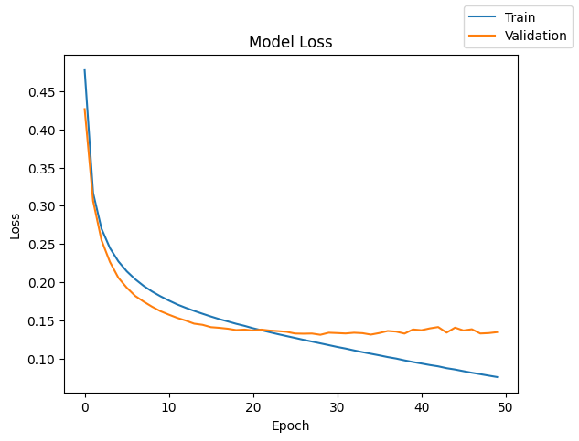

```python
# plot the loss
plot_metric(history5,'loss')
```

**Loss Graph Observations:**

- Training loss starts high (~0.47) and decreases steadily to ~0.08, showing strong learning progression
- Validation loss starts similarly (~0.43) and stabilizes around 0.13-0.14 after epoch 15
- Moderate gap between training and validation loss indicates some overfitting but well-controlled

#### Recall analysis

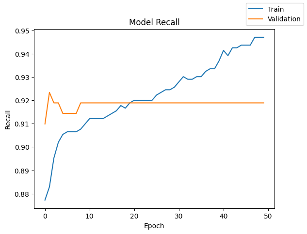

```python
# plot the recall
plot_metric(history5,'recall')
```

**Recall Graph Observations:**

- Training recall starts low (~0.88) and steadily improves to ~0.95 by epoch 50
- Validation recall starts high (~0.91) and remains stable around 0.92 throughout training
- Training recall eventually surpasses validation recall, indicating model memorization

#### Confusion matrix analysis

```
500/500 ━━━━━━━━━━━━━━━━━━━━ 0s 217us/step
125/125 ━━━━━━━━━━━━━━━━━━━━ 0s 243us/step
```

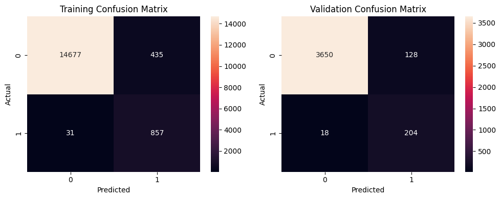

```python
# plot the confusion matrix for train and validation data|
plot_confusion_matrices_v2(model5, X_train_normalized, y_train, X_val_normalized, y_val)
```

**Confusion matrix observations**

- Confusion matrix shows 18 FN (critical missed failures)
- FP has remained almost similar to Model 4's at 128 (unnecessary inspections)

### Model Results

```python
# Add model results to summary
results.loc[4] = ['Model 5',
    3,                              # hidden_layers
    [256, 128, 64],                 # neurons_in_hidden_layers
    ["relu", "relu", "relu"],       # activation_function_in__hidden_layer
    50,                             # epochs
    64,                             # batch_size
    "SGD",                          # optimizer
    [0.001, 0.9],                    # learning_rate, momentum
    "Xavier (aka Glorot)",          # kernel_weights_init
    "-",                            # regularization
    history5.history["loss"][-1],   # train_loss
    history5.history["val_loss"][-1],  # validation_loss
    history5.history["recall"][-1],    # train_recall
    history5.history["val_recall"][-1],# validation_recall
    round(end - start, 2)           # duration
]
results
```

|  | model_name | hidden_layers | hidden_layer_neurons | hidden_layer_activations | epochs | batch_size | optimizer | learning_rate, momentum | kernel_weights_init | regularization | train_loss | validation_loss | train_recall | validation_recall | duration |
| --- | --- | --- | --- | --- | --- | --- | --- | --- | --- | --- | --- | --- | --- | --- | --- |
| 0 | Model 1 | 2 | [128, 64] | [relu, relu] | 50 | 64 | SGD | [0.01, -] | Xavier (aka Glorot) | - | 0.122834 | 0.128425 | 0.918919 | 0.918919 | 6.20 |
| 1 | Model 2 | 2 | [128, 64] | [relu, relu] | 50 | 128 | SGD | [0.01, -] | Xavier (aka Glorot) | - | 0.156367 | 0.142436 | 0.914414 | 0.918919 | 4.19 |
| 2 | Model 3 | 3 | [256, 128, 64] | [relu, relu, relu] | 50 | 64 | SGD | [0.01, -] | Xavier (aka Glorot) | - | 0.073536 | 0.112700 | 0.953829 | 0.918919 | 8.36 |
| 3 | Model 4 | 3 | [256, 128, 64] | [relu, relu, relu] | 50 | 64 | SGD | [0.001, -] | Xavier (aka Glorot) | - | 0.203309 | 0.170217 | 0.906532 | 0.914414 | 8.62 |
| 4 | Model 5 | 3 | [256, 128, 64] | [relu, relu, relu] | 50 | 64 | SGD | [0.001, 0.9] | Xavier (aka Glorot) | - | 0.075856 | 0.134640 | 0.947072 | 0.918919 | 8.75 |

## Model 6: 'Adam' Optimizer

```python
# clears the current Keras session, resets all layers, models previously created
tf.keras.backend.clear_session()
```

### Create Model

- Adam optimiser will be used as the models so have shown improvements with learning rate and momentum configurations
- Adam optimiser works on 2 important aspects - Momentum and Adaptive learning rates
- Adam optimiser's default learning rate is 0.001. Adam optimiser will be configured for a much lower learning rate of 0.0001
- Rest of the configuration will remain the same

```python
#Initializing the neural network
model6 = Sequential()
model6.add(Input(shape=(X_train_normalized.shape[1],)))

# add 3 hidden layers with 256,128,64
model6.add(Dense(256,activation='relu'))
model6.add(Dense(128,activation='relu'))
model6.add(Dense(64,activation='relu'))

# sigmoid output
model6.add(Dense(1,activation='sigmoid'))
print(model6.summary())

# defining Adam optimizer with 0.0001 learning rate
optimizer = tf.keras.optimizers.Adam(learning_rate=0.0001)

# compile with binary_crossentropy loss and Adam
model6.compile(loss='binary_crossentropy', optimizer=optimizer, metrics=['recall'])
```

```
Model: "sequential"
```

```
┏━━━━━━━━━━━━━━━━━━━━━━━━━━━━━━━━━┳━━━━━━━━━━━━━━━━━━━━━━━━┳━━━━━━━━━━━━━━━┓
┃ Layer (type)                    ┃ Output Shape           ┃       Param # ┃
┡━━━━━━━━━━━━━━━━━━━━━━━━━━━━━━━━━╇━━━━━━━━━━━━━━━━━━━━━━━━╇━━━━━━━━━━━━━━━┩
│ dense (Dense)                   │ (None, 256)            │        10,496 │
├─────────────────────────────────┼────────────────────────┼───────────────┤
│ dense_1 (Dense)                 │ (None, 128)            │        32,896 │
├─────────────────────────────────┼────────────────────────┼───────────────┤
│ dense_2 (Dense)                 │ (None, 64)             │         8,256 │
├─────────────────────────────────┼────────────────────────┼───────────────┤
│ dense_3 (Dense)                 │ (None, 1)              │            65 │
└─────────────────────────────────┴────────────────────────┴───────────────┘
```

```
 Total params: 51,713 (202.00 KB)
```

```
 Trainable params: 51,713 (202.00 KB)
```

```
 Non-trainable params: 0 (0.00 B)
```

```
None
```

### Training the model

```python
# fit the model and capture start, end times
start = time.time()
history6 = model6.fit(X_train_normalized, y_train,
                    validation_data=(X_val_normalized, y_val) ,
                    batch_size=batch_size,
                    epochs=epochs,
                    class_weight=class_weight_dict)
end=time.time()

print("Time taken in seconds ",end-start)
```

```
250/250 ━━━━━━━━━━━━━━━━━━━━ 1s 1ms/step - loss: 0.5586 - recall: 0.7615 - val_loss: 0.3928 - val_recall: 0.9054
175/250 ━━━━━━━━━━━━━━━━━━━━ 0s 576us/step - loss: 0.3251 - recall: 0.8914
```

```
250/250 ━━━━━━━━━━━━━━━━━━━━ 0s 751us/step - loss: 0.3183 - recall: 0.8916 - val_loss: 0.2879 - val_recall: 0.9144
250/250 ━━━━━━━━━━━━━━━━━━━━ 0s 742us/step - loss: 0.2611 - recall: 0.9091 - val_loss: 0.2418 - val_recall: 0.9189
250/250 ━━━━━━━━━━━━━━━━━━━━ 0s 735us/step - loss: 0.2319 - recall: 0.9127 - val_loss: 0.2149 - val_recall: 0.9189
250/250 ━━━━━━━━━━━━━━━━━━━━ 0s 726us/step - loss: 0.2121 - recall: 0.9115 - val_loss: 0.1985 - val_recall: 0.9144
250/250 ━━━━━━━━━━━━━━━━━━━━ 0s 738us/step - loss: 0.1984 - recall: 0.9115 - val_loss: 0.1857 - val_recall: 0.9189
250/250 ━━━━━━━━━━━━━━━━━━━━ 0s 734us/step - loss: 0.1865 - recall: 0.9121 - val_loss: 0.1768 - val_recall: 0.9189
250/250 ━━━━━━━━━━━━━━━━━━━━ 0s 763us/step - loss: 0.1769 - recall: 0.9121 - val_loss: 0.1703 - val_recall: 0.9189
250/250 ━━━━━━━━━━━━━━━━━━━━ 0s 740us/step - loss: 0.1689 - recall: 0.9121 - val_loss: 0.1646 - val_recall: 0.9189
250/250 ━━━━━━━━━━━━━━━━━━━━ 0s 723us/step - loss: 0.1619 - recall: 0.9169 - val_loss: 0.1590 - val_recall: 0.9189
250/250 ━━━━━━━━━━━━━━━━━━━━ 0s 712us/step - loss: 0.1554 - recall: 0.9180 - val_loss: 0.1549 - val_recall: 0.9189
250/250 ━━━━━━━━━━━━━━━━━━━━ 0s 692us/step - loss: 0.1498 - recall: 0.9203 - val_loss: 0.1515 - val_recall: 0.9189
250/250 ━━━━━━━━━━━━━━━━━━━━ 0s 685us/step - loss: 0.1447 - recall: 0.9208 - val_loss: 0.1491 - val_recall: 0.9189
250/250 ━━━━━━━━━━━━━━━━━━━━ 0s 687us/step - loss: 0.1398 - recall: 0.9222 - val_loss: 0.1477 - val_recall: 0.9189
250/250 ━━━━━━━━━━━━━━━━━━━━ 0s 682us/step - loss: 0.1356 - recall: 0.9244 - val_loss: 0.1463 - val_recall: 0.9189
250/250 ━━━━━━━━━━━━━━━━━━━━ 0s 681us/step - loss: 0.1316 - recall: 0.9244 - val_loss: 0.1446 - val_recall: 0.9189
250/250 ━━━━━━━━━━━━━━━━━━━━ 0s 680us/step - loss: 0.1277 - recall: 0.9244 - val_loss: 0.1424 - val_recall: 0.9189
250/250 ━━━━━━━━━━━━━━━━━━━━ 0s 688us/step - loss: 0.1242 - recall: 0.9244 - val_loss: 0.1407 - val_recall: 0.9189
250/250 ━━━━━━━━━━━━━━━━━━━━ 0s 669us/step - loss: 0.1207 - recall: 0.9250 - val_loss: 0.1394 - val_recall: 0.9189
250/250 ━━━━━━━━━━━━━━━━━━━━ 0s 681us/step - loss: 0.1174 - recall: 0.9262 - val_loss: 0.1380 - val_recall: 0.9189
250/250 ━━━━━━━━━━━━━━━━━━━━ 0s 689us/step - loss: 0.1144 - recall: 0.9262 - val_loss: 0.1365 - val_recall: 0.9189
250/250 ━━━━━━━━━━━━━━━━━━━━ 0s 715us/step - loss: 0.1112 - recall: 0.9263 - val_loss: 0.1358 - val_recall: 0.9189
250/250 ━━━━━━━━━━━━━━━━━━━━ 0s 741us/step - loss: 0.1083 - recall: 0.9269 - val_loss: 0.1336 - val_recall: 0.9189
250/250 ━━━━━━━━━━━━━━━━━━━━ 0s 755us/step - loss: 0.1053 - recall: 0.9270 - val_loss: 0.1318 - val_recall: 0.9189
250/250 ━━━━━━━━━━━━━━━━━━━━ 0s 749us/step - loss: 0.1025 - recall: 0.9270 - val_loss: 0.1305 - val_recall: 0.9189
250/250 ━━━━━━━━━━━━━━━━━━━━ 0s 748us/step - loss: 0.0995 - recall: 0.9281 - val_loss: 0.1322 - val_recall: 0.9189
250/250 ━━━━━━━━━━━━━━━━━━━━ 0s 747us/step - loss: 0.0968 - recall: 0.9281 - val_loss: 0.1293 - val_recall: 0.9189
250/250 ━━━━━━━━━━━━━━━━━━━━ 0s 734us/step - loss: 0.0941 - recall: 0.9286 - val_loss: 0.1269 - val_recall: 0.9189
250/250 ━━━━━━━━━━━━━━━━━━━━ 0s 745us/step - loss: 0.0916 - recall: 0.9288 - val_loss: 0.1256 - val_recall: 0.9189
250/250 ━━━━━━━━━━━━━━━━━━━━ 0s 762us/step - loss: 0.0888 - recall: 0.9289 - val_loss: 0.1250 - val_recall: 0.9189
250/250 ━━━━━━━━━━━━━━━━━━━━ 0s 769us/step - loss: 0.0863 - recall: 0.9289 - val_loss: 0.1227 - val_recall: 0.9189
250/250 ━━━━━━━━━━━━━━━━━━━━ 0s 751us/step - loss: 0.0838 - recall: 0.9310 - val_loss: 0.1229 - val_recall: 0.9189
250/250 ━━━━━━━━━━━━━━━━━━━━ 0s 776us/step - loss: 0.0814 - recall: 0.9330 - val_loss: 0.1228 - val_recall: 0.9189
250/250 ━━━━━━━━━━━━━━━━━━━━ 0s 737us/step - loss: 0.0790 - recall: 0.9364 - val_loss: 0.1208 - val_recall: 0.9189
250/250 ━━━━━━━━━━━━━━━━━━━━ 0s 737us/step - loss: 0.0766 - recall: 0.9383 - val_loss: 0.1179 - val_recall: 0.9189
250/250 ━━━━━━━━━━━━━━━━━━━━ 0s 759us/step - loss: 0.0742 - recall: 0.9399 - val_loss: 0.1186 - val_recall: 0.9189
250/250 ━━━━━━━━━━━━━━━━━━━━ 0s 743us/step - loss: 0.0717 - recall: 0.9524 - val_loss: 0.1182 - val_recall: 0.9189
250/250 ━━━━━━━━━━━━━━━━━━━━ 0s 745us/step - loss: 0.0696 - recall: 0.9609 - val_loss: 0.1172 - val_recall: 0.9189
250/250 ━━━━━━━━━━━━━━━━━━━━ 0s 772us/step - loss: 0.0673 - recall: 0.9634 - val_loss: 0.1155 - val_recall: 0.9189
250/250 ━━━━━━━━━━━━━━━━━━━━ 0s 754us/step - loss: 0.0650 - recall: 0.9634 - val_loss: 0.1136 - val_recall: 0.9189
250/250 ━━━━━━━━━━━━━━━━━━━━ 0s 779us/step - loss: 0.0627 - recall: 0.9634 - val_loss: 0.1139 - val_recall: 0.9189
250/250 ━━━━━━━━━━━━━━━━━━━━ 0s 778us/step - loss: 0.0610 - recall: 0.9655 - val_loss: 0.1120 - val_recall: 0.9189
250/250 ━━━━━━━━━━━━━━━━━━━━ 0s 757us/step - loss: 0.0583 - recall: 0.9675 - val_loss: 0.1111 - val_recall: 0.9189
250/250 ━━━━━━━━━━━━━━━━━━━━ 0s 782us/step - loss: 0.0562 - recall: 0.9696 - val_loss: 0.1099 - val_recall: 0.9189
250/250 ━━━━━━━━━━━━━━━━━━━━ 0s 749us/step - loss: 0.0544 - recall: 0.9708 - val_loss: 0.1099 - val_recall: 0.9189
250/250 ━━━━━━━━━━━━━━━━━━━━ 0s 747us/step - loss: 0.0523 - recall: 0.9726 - val_loss: 0.1088 - val_recall: 0.9189
250/250 ━━━━━━━━━━━━━━━━━━━━ 0s 735us/step - loss: 0.0505 - recall: 0.9727 - val_loss: 0.1075 - val_recall: 0.9189
250/250 ━━━━━━━━━━━━━━━━━━━━ 0s 712us/step - loss: 0.0483 - recall: 0.9753 - val_loss: 0.1075 - val_recall: 0.9189
250/250 ━━━━━━━━━━━━━━━━━━━━ 0s 725us/step - loss: 0.0462 - recall: 0.9808 - val_loss: 0.1058 - val_recall: 0.9189
250/250 ━━━━━━━━━━━━━━━━━━━━ 0s 737us/step - loss: 0.0447 - recall: 0.9764 - val_loss: 0.1053 - val_recall: 0.9189
Time taken in seconds  9.95661973953247
```

### Model Analysis

#### Loss analysis

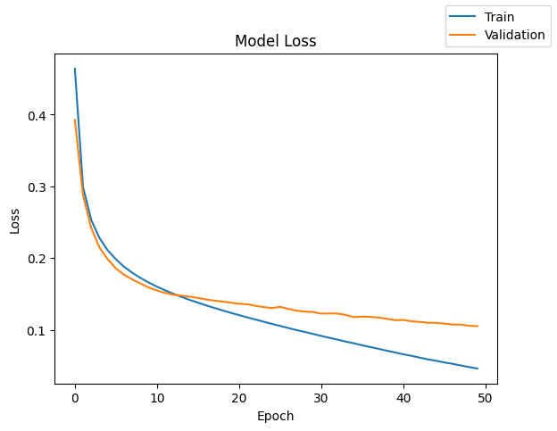

```python
# plot the loss
plot_metric(history6,'loss')
```

**Loss Graph Observations:**

- Training loss decreases from ~0.45 to ~0.05, validation loss from ~0.37 to ~0.11
- Significant gap emerges with training loss much lower than validation loss
- Clear overfitting pattern with diverging loss curves after epoch 20

#### Recall analysis

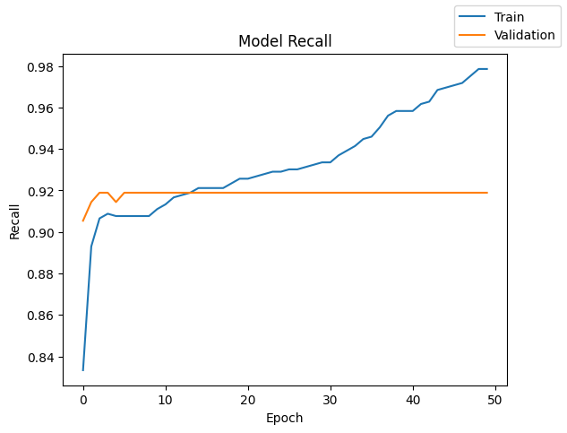

```python
# plot the recall
plot_metric(history6,'recall')
```

**Recall Graph Observations:**

- Training recall climbs continuously from ~0.83 to ~0.98 showing aggressive learning
- Validation recall plateaus at ~0.92 (completely flat throughout training, after ~5 epochs)
- Severe overfitting with 6% gap between training (0.98) and validation (0.92) recall

#### Confusion matrix analysis

```
500/500 ━━━━━━━━━━━━━━━━━━━━ 0s 222us/step
125/125 ━━━━━━━━━━━━━━━━━━━━ 0s 242us/step
```

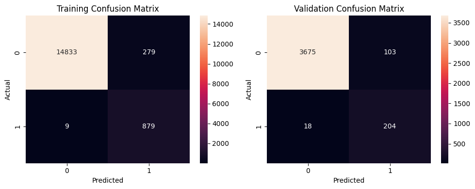

```python
# plot the confusion matrix for train and validation data
plot_confusion_matrices_v2(model6, X_train_normalized, y_train, X_val_normalized, y_val)
```

**Confusion matrix observations**

### Model Results

```python
# Add model results to summary
results.loc[5] = ['Model 6',
    3,                              # hidden_layers
    [256, 128, 64],                 # neurons_in_hidden_layers
    ["relu", "relu", "relu"],       # activation_function_in__hidden_layer
    50,                             # epochs
    64,                             # batch_size
    "Adam",                          # optimizer
    [0.0001, "-"],                    # learning_rate, momentum
    "Xavier (aka Glorot)",          # kernel_weights_init
    "-",                            # regularization
    history6.history["loss"][-1],   # train_loss
    history6.history["val_loss"][-1],  # validation_loss
    history6.history["recall"][-1],    # train_recall
    history6.history["val_recall"][-1],# validation_recall
    round(end - start, 2)           # duration
]
results
```

|  | model_name | hidden_layers | hidden_layer_neurons | hidden_layer_activations | epochs | batch_size | optimizer | learning_rate, momentum | kernel_weights_init | regularization | train_loss | validation_loss | train_recall | validation_recall | duration |
| --- | --- | --- | --- | --- | --- | --- | --- | --- | --- | --- | --- | --- | --- | --- | --- |
| 0 | Model 1 | 2 | [128, 64] | [relu, relu] | 50 | 64 | SGD | [0.01, -] | Xavier (aka Glorot) | - | 0.122834 | 0.128425 | 0.918919 | 0.918919 | 6.20 |
| 1 | Model 2 | 2 | [128, 64] | [relu, relu] | 50 | 128 | SGD | [0.01, -] | Xavier (aka Glorot) | - | 0.156367 | 0.142436 | 0.914414 | 0.918919 | 4.19 |
| 2 | Model 3 | 3 | [256, 128, 64] | [relu, relu, relu] | 50 | 64 | SGD | [0.01, -] | Xavier (aka Glorot) | - | 0.073536 | 0.112700 | 0.953829 | 0.918919 | 8.36 |
| 3 | Model 4 | 3 | [256, 128, 64] | [relu, relu, relu] | 50 | 64 | SGD | [0.001, -] | Xavier (aka Glorot) | - | 0.203309 | 0.170217 | 0.906532 | 0.914414 | 8.62 |
| 4 | Model 5 | 3 | [256, 128, 64] | [relu, relu, relu] | 50 | 64 | SGD | [0.001, 0.9] | Xavier (aka Glorot) | - | 0.075856 | 0.134640 | 0.947072 | 0.918919 | 8.75 |
| 5 | Model 6 | 3 | [256, 128, 64] | [relu, relu, relu] | 50 | 64 | Adam | [0.0001, -] | Xavier (aka Glorot) | - | 0.046293 | 0.105299 | 0.978604 | 0.918919 | 9.96 |

## Model 7: Add 'dropout' layers

```python
# clears the current Keras session, resets all layers, models previously created
tf.keras.backend.clear_session()
```

### Create Model

- Dropouts of 0.5, 0.4, 0.3 will be added to the hidden layers respectively. Dropouts help in regularisation and are added in a progressively decreasing fashion
- Rest of the configuration will remain the same

```python
#Initializing the neural network
model7 = Sequential()
model7.add(Input(shape=(X_train_normalized.shape[1],)))

# add 3 hidden layers with 256, 128, 64
model7.add(Dense(256,activation='relu'))
model7.add(Dropout(0.5))
model7.add(Dense(128,activation='relu'))
model7.add(Dropout(0.4))
model7.add(Dense(64,activation='relu'))
model7.add(Dropout(0.3))

# sigmoid output
model7.add(Dense(1,activation='sigmoid'))
print(model7.summary())

# defining Adam optimizer with learning rate 0.0001
optimizer = tf.keras.optimizers.Adam(learning_rate=0.0001)

# compile with binary_crossentropy loss and Adam
model7.compile(loss='binary_crossentropy', optimizer=optimizer, metrics=['recall'])
```

```
Model: "sequential"
```

```
┏━━━━━━━━━━━━━━━━━━━━━━━━━━━━━━━━━┳━━━━━━━━━━━━━━━━━━━━━━━━┳━━━━━━━━━━━━━━━┓
┃ Layer (type)                    ┃ Output Shape           ┃       Param # ┃
┡━━━━━━━━━━━━━━━━━━━━━━━━━━━━━━━━━╇━━━━━━━━━━━━━━━━━━━━━━━━╇━━━━━━━━━━━━━━━┩
│ dense (Dense)                   │ (None, 256)            │        10,496 │
├─────────────────────────────────┼────────────────────────┼───────────────┤
│ dropout (Dropout)               │ (None, 256)            │             0 │
├─────────────────────────────────┼────────────────────────┼───────────────┤
│ dense_1 (Dense)                 │ (None, 128)            │        32,896 │
├─────────────────────────────────┼────────────────────────┼───────────────┤
│ dropout_1 (Dropout)             │ (None, 128)            │             0 │
├─────────────────────────────────┼────────────────────────┼───────────────┤
│ dense_2 (Dense)                 │ (None, 64)             │         8,256 │
├─────────────────────────────────┼────────────────────────┼───────────────┤
│ dropout_2 (Dropout)             │ (None, 64)             │             0 │
├─────────────────────────────────┼────────────────────────┼───────────────┤
│ dense_3 (Dense)                 │ (None, 1)              │            65 │
└─────────────────────────────────┴────────────────────────┴───────────────┘
```

```
 Total params: 51,713 (202.00 KB)
```

```
 Trainable params: 51,713 (202.00 KB)
```

```
 Non-trainable params: 0 (0.00 B)
```

```
None
```

### Training the model

```python
# fit the model and capture start, end times
start = time.time()
history7 = model7.fit(X_train_normalized, y_train,
                    validation_data=(X_val_normalized, y_val) ,
                    batch_size=batch_size,
                    epochs=epochs,
                    class_weight=class_weight_dict)
end=time.time()

print("Time taken in seconds ",end-start)
```

```
250/250 ━━━━━━━━━━━━━━━━━━━━ 1s 1ms/step - loss: 0.6861 - recall: 0.4229 - val_loss: 0.5381 - val_recall: 0.8423
 70/250 ━━━━━━━━━━━━━━━━━━━━ 0s 732us/step - loss: 0.5056 - recall: 0.8287
```

```
250/250 ━━━━━━━━━━━━━━━━━━━━ 0s 890us/step - loss: 0.5047 - recall: 0.8147 - val_loss: 0.4363 - val_recall: 0.8829
250/250 ━━━━━━━━━━━━━━━━━━━━ 0s 876us/step - loss: 0.4532 - recall: 0.8409 - val_loss: 0.3780 - val_recall: 0.9099
250/250 ━━━━━━━━━━━━━━━━━━━━ 0s 881us/step - loss: 0.3868 - recall: 0.8586 - val_loss: 0.3101 - val_recall: 0.9144
250/250 ━━━━━━━━━━━━━━━━━━━━ 0s 880us/step - loss: 0.3552 - recall: 0.8660 - val_loss: 0.2825 - val_recall: 0.9234
250/250 ━━━━━━━━━━━━━━━━━━━━ 0s 882us/step - loss: 0.3595 - recall: 0.8773 - val_loss: 0.2556 - val_recall: 0.9234
250/250 ━━━━━━━━━━━━━━━━━━━━ 0s 891us/step - loss: 0.3389 - recall: 0.8575 - val_loss: 0.2405 - val_recall: 0.9189
250/250 ━━━━━━━━━━━━━━━━━━━━ 0s 868us/step - loss: 0.3173 - recall: 0.8744 - val_loss: 0.2245 - val_recall: 0.9144
250/250 ━━━━━━━━━━━━━━━━━━━━ 0s 870us/step - loss: 0.3106 - recall: 0.8732 - val_loss: 0.2123 - val_recall: 0.9144
250/250 ━━━━━━━━━━━━━━━━━━━━ 0s 890us/step - loss: 0.3024 - recall: 0.8713 - val_loss: 0.2118 - val_recall: 0.9144
250/250 ━━━━━━━━━━━━━━━━━━━━ 0s 885us/step - loss: 0.2876 - recall: 0.8852 - val_loss: 0.1957 - val_recall: 0.9144
250/250 ━━━━━━━━━━━━━━━━━━━━ 0s 852us/step - loss: 0.2731 - recall: 0.8980 - val_loss: 0.1908 - val_recall: 0.9144
250/250 ━━━━━━━━━━━━━━━━━━━━ 0s 885us/step - loss: 0.2849 - recall: 0.8853 - val_loss: 0.1936 - val_recall: 0.9144
250/250 ━━━━━━━━━━━━━━━━━━━━ 0s 865us/step - loss: 0.2737 - recall: 0.8942 - val_loss: 0.1836 - val_recall: 0.9144
250/250 ━━━━━━━━━━━━━━━━━━━━ 0s 889us/step - loss: 0.2672 - recall: 0.8962 - val_loss: 0.1861 - val_recall: 0.9144
250/250 ━━━━━━━━━━━━━━━━━━━━ 0s 871us/step - loss: 0.2627 - recall: 0.8910 - val_loss: 0.1783 - val_recall: 0.9144
250/250 ━━━━━━━━━━━━━━━━━━━━ 0s 836us/step - loss: 0.2456 - recall: 0.8973 - val_loss: 0.1706 - val_recall: 0.9144
250/250 ━━━━━━━━━━━━━━━━━━━━ 0s 814us/step - loss: 0.2451 - recall: 0.8959 - val_loss: 0.1689 - val_recall: 0.9144
250/250 ━━━━━━━━━━━━━━━━━━━━ 0s 802us/step - loss: 0.2507 - recall: 0.8960 - val_loss: 0.1708 - val_recall: 0.9144
250/250 ━━━━━━━━━━━━━━━━━━━━ 0s 787us/step - loss: 0.2458 - recall: 0.8894 - val_loss: 0.1691 - val_recall: 0.9144
250/250 ━━━━━━━━━━━━━━━━━━━━ 0s 805us/step - loss: 0.2379 - recall: 0.8908 - val_loss: 0.1647 - val_recall: 0.9144
250/250 ━━━━━━━━━━━━━━━━━━━━ 0s 810us/step - loss: 0.2271 - recall: 0.8990 - val_loss: 0.1595 - val_recall: 0.9144
250/250 ━━━━━━━━━━━━━━━━━━━━ 0s 809us/step - loss: 0.2420 - recall: 0.8956 - val_loss: 0.1562 - val_recall: 0.9144
250/250 ━━━━━━━━━━━━━━━━━━━━ 0s 797us/step - loss: 0.2347 - recall: 0.8875 - val_loss: 0.1526 - val_recall: 0.9144
250/250 ━━━━━━━━━━━━━━━━━━━━ 0s 786us/step - loss: 0.2259 - recall: 0.8929 - val_loss: 0.1612 - val_recall: 0.9144
250/250 ━━━━━━━━━━━━━━━━━━━━ 0s 902us/step - loss: 0.2208 - recall: 0.8988 - val_loss: 0.1549 - val_recall: 0.9144
250/250 ━━━━━━━━━━━━━━━━━━━━ 0s 857us/step - loss: 0.2233 - recall: 0.9000 - val_loss: 0.1573 - val_recall: 0.9144
250/250 ━━━━━━━━━━━━━━━━━━━━ 0s 876us/step - loss: 0.2152 - recall: 0.8872 - val_loss: 0.1495 - val_recall: 0.9144
250/250 ━━━━━━━━━━━━━━━━━━━━ 0s 861us/step - loss: 0.2141 - recall: 0.8976 - val_loss: 0.1510 - val_recall: 0.9144
250/250 ━━━━━━━━━━━━━━━━━━━━ 0s 885us/step - loss: 0.2128 - recall: 0.8954 - val_loss: 0.1476 - val_recall: 0.9144
250/250 ━━━━━━━━━━━━━━━━━━━━ 0s 900us/step - loss: 0.2103 - recall: 0.8952 - val_loss: 0.1453 - val_recall: 0.9144
250/250 ━━━━━━━━━━━━━━━━━━━━ 0s 872us/step - loss: 0.2045 - recall: 0.8982 - val_loss: 0.1442 - val_recall: 0.9144
250/250 ━━━━━━━━━━━━━━━━━━━━ 0s 881us/step - loss: 0.1983 - recall: 0.8993 - val_loss: 0.1475 - val_recall: 0.9144
250/250 ━━━━━━━━━━━━━━━━━━━━ 0s 870us/step - loss: 0.2084 - recall: 0.9011 - val_loss: 0.1466 - val_recall: 0.9144
250/250 ━━━━━━━━━━━━━━━━━━━━ 0s 883us/step - loss: 0.1909 - recall: 0.9019 - val_loss: 0.1454 - val_recall: 0.9144
250/250 ━━━━━━━━━━━━━━━━━━━━ 0s 887us/step - loss: 0.2002 - recall: 0.8901 - val_loss: 0.1436 - val_recall: 0.9189
250/250 ━━━━━━━━━━━━━━━━━━━━ 0s 963us/step - loss: 0.2023 - recall: 0.8896 - val_loss: 0.1442 - val_recall: 0.9189
250/250 ━━━━━━━━━━━━━━━━━━━━ 0s 936us/step - loss: 0.1969 - recall: 0.8992 - val_loss: 0.1420 - val_recall: 0.9144
250/250 ━━━━━━━━━━━━━━━━━━━━ 0s 862us/step - loss: 0.1985 - recall: 0.9026 - val_loss: 0.1502 - val_recall: 0.9189
250/250 ━━━━━━━━━━━━━━━━━━━━ 0s 858us/step - loss: 0.2052 - recall: 0.8967 - val_loss: 0.1478 - val_recall: 0.9099
250/250 ━━━━━━━━━━━━━━━━━━━━ 0s 881us/step - loss: 0.1906 - recall: 0.9058 - val_loss: 0.1360 - val_recall: 0.9189
250/250 ━━━━━━━━━━━━━━━━━━━━ 0s 867us/step - loss: 0.1880 - recall: 0.8993 - val_loss: 0.1354 - val_recall: 0.9144
250/250 ━━━━━━━━━━━━━━━━━━━━ 0s 940us/step - loss: 0.1860 - recall: 0.9030 - val_loss: 0.1311 - val_recall: 0.9144
250/250 ━━━━━━━━━━━━━━━━━━━━ 0s 950us/step - loss: 0.1776 - recall: 0.8983 - val_loss: 0.1284 - val_recall: 0.9189
250/250 ━━━━━━━━━━━━━━━━━━━━ 0s 903us/step - loss: 0.1832 - recall: 0.8981 - val_loss: 0.1360 - val_recall: 0.9189
250/250 ━━━━━━━━━━━━━━━━━━━━ 0s 886us/step - loss: 0.1794 - recall: 0.9059 - val_loss: 0.1311 - val_recall: 0.9099
250/250 ━━━━━━━━━━━━━━━━━━━━ 0s 859us/step - loss: 0.1786 - recall: 0.9028 - val_loss: 0.1300 - val_recall: 0.9144
250/250 ━━━━━━━━━━━━━━━━━━━━ 0s 895us/step - loss: 0.1822 - recall: 0.8994 - val_loss: 0.1239 - val_recall: 0.9144
250/250 ━━━━━━━━━━━━━━━━━━━━ 0s 852us/step - loss: 0.1851 - recall: 0.8969 - val_loss: 0.1297 - val_recall: 0.9189
250/250 ━━━━━━━━━━━━━━━━━━━━ 0s 839us/step - loss: 0.1808 - recall: 0.9094 - val_loss: 0.1238 - val_recall: 0.9144
Time taken in seconds  11.715553760528564
```

### Model Analysis

#### Loss analysis

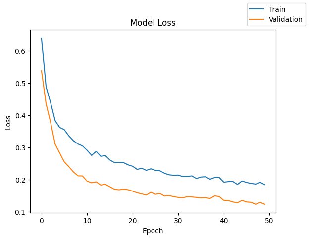

```python
# plot the loss
plot_metric(history7,'loss')
```

**Loss Graph Observations:**

- Training loss decreases from ~0.65 to ~0.18, validation loss from ~0.55 to ~0.12
- Validation loss consistently lower than training loss indicating good regularization
- Convergence with dropout preventing overfitting effectively

#### Recall analysis

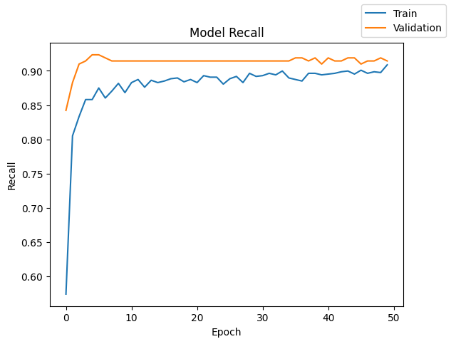

```python
# plot the recall
plot_metric(history7,'recall')
```

**Recall Graph Observations:**

- Training recall plateaus at ~0.90 with oscillations, validation recall at ~0.91
- Validation recall slightly exceeds training recall showing excellent generalization
- Stable performance with minimal train-validation gap (~1%)

#### Confusion matrix analysis

```
500/500 ━━━━━━━━━━━━━━━━━━━━ 0s 223us/step
125/125 ━━━━━━━━━━━━━━━━━━━━ 0s 242us/step
```

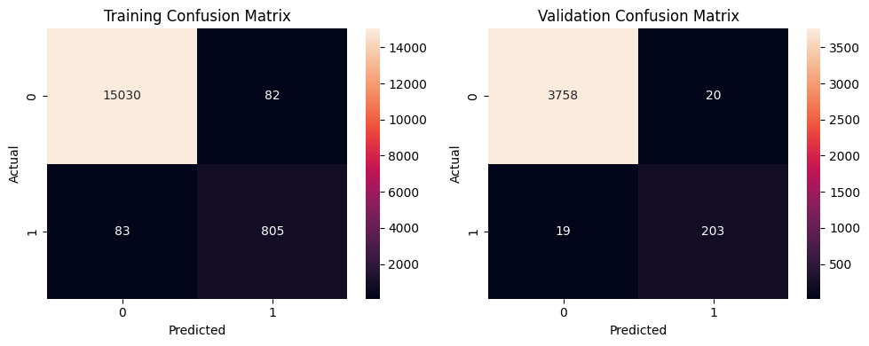

```python
# plot the confusion matrix for train and validation data
plot_confusion_matrices_v2(model7, X_train_normalized, y_train, X_val_normalized, y_val)
```

**Confusion matrix observations**

- False negatives have remained around 19
- There is a steep drop in false positives to 20 from the usual 80-120 range observed. This also implies a better recall precision balance

### Model Results

```python
# Add model results to summary
results.loc[6] = ['Model 7',
    3,                              # hidden_layers
    [256, 128, 64],                 # neurons_in_hidden_layers
    ["relu", "relu", "relu"],       # activation_function_in__hidden_layer
    50,                             # epochs
    64,                             # batch_size
    "Adam",                          # optimizer
    [0.0001, "-"],                   # learning_rate, momentum
    "Xavier (aka Glorot)",          # kernel_weights_init
    "dropout(0.5, 0.4, 0.3)",       # regularization
    history7.history["loss"][-1],   # train_loss
    history7.history["val_loss"][-1],  # validation_loss
    history7.history["recall"][-1],    # train_recall
    history7.history["val_recall"][-1],# validation_recall
    round(end - start, 2)           # duration
]
results
```

|  | model_name | hidden_layers | hidden_layer_neurons | hidden_layer_activations | epochs | batch_size | optimizer | learning_rate, momentum | kernel_weights_init | regularization | train_loss | validation_loss | train_recall | validation_recall | duration |
| --- | --- | --- | --- | --- | --- | --- | --- | --- | --- | --- | --- | --- | --- | --- | --- |
| 0 | Model 1 | 2 | [128, 64] | [relu, relu] | 50 | 64 | SGD | [0.01, -] | Xavier (aka Glorot) | - | 0.122834 | 0.128425 | 0.918919 | 0.918919 | 6.20 |
| 1 | Model 2 | 2 | [128, 64] | [relu, relu] | 50 | 128 | SGD | [0.01, -] | Xavier (aka Glorot) | - | 0.156367 | 0.142436 | 0.914414 | 0.918919 | 4.19 |
| 2 | Model 3 | 3 | [256, 128, 64] | [relu, relu, relu] | 50 | 64 | SGD | [0.01, -] | Xavier (aka Glorot) | - | 0.073536 | 0.112700 | 0.953829 | 0.918919 | 8.36 |
| 3 | Model 4 | 3 | [256, 128, 64] | [relu, relu, relu] | 50 | 64 | SGD | [0.001, -] | Xavier (aka Glorot) | - | 0.203309 | 0.170217 | 0.906532 | 0.914414 | 8.62 |
| 4 | Model 5 | 3 | [256, 128, 64] | [relu, relu, relu] | 50 | 64 | SGD | [0.001, 0.9] | Xavier (aka Glorot) | - | 0.075856 | 0.134640 | 0.947072 | 0.918919 | 8.75 |
| 5 | Model 6 | 3 | [256, 128, 64] | [relu, relu, relu] | 50 | 64 | Adam | [0.0001, -] | Xavier (aka Glorot) | - | 0.046293 | 0.105299 | 0.978604 | 0.918919 | 9.96 |
| 6 | Model 7 | 3 | [256, 128, 64] | [relu, relu, relu] | 50 | 64 | Adam | [0.0001, -] | Xavier (aka Glorot) | dropout(0.5, 0.4, 0.3) | 0.184809 | 0.123838 | 0.908784 | 0.914414 | 11.72 |

### Summary

- Dropout layers eliminate overfitting and this is observed through validation metrics exceeding training metrics
- Only 19 FN (missed failures) one of the lowest critical error count among all models
- Dramatically reduced false positives: 20 vs previous models in 80s and 120s
- Best precision-recall balance with superior generalization capability
- Adding more dropouts and a smaller learning rate of 0.0001 has resulted in the model running for ~11seconds

## Model 8: Add 'Batch Normalization'

```python
# clears the current Keras session, resets all layers, models previously created
tf.keras.backend.clear_session()
```

### Create Model

- BatchNormalization will be added (with dropouts) to stabilise the gradients and smoothen the convergence. BatchNormalization and Dropouts are complimentary regularization techniques
- `Dense -> BatchNormation -> Activaton with ReLU -> Dropout` will be the sequence
- Rest of the configuration will remain the same

```python
#Initializing the neural network
model8 = Sequential()
model8.add(Input(shape=(X_train_normalized.shape[1],)))

# add 3 hidden layers with 256, 128, 64
model8.add(Dense(256))             # No activation yet
model8.add(BatchNormalization())  # Normalizes before activation using BatchNormalization
model8.add(Activation('relu'))    # ReLU Activation
model8.add(Dropout(0.5))          # Add dropout

model8.add(Dense(128))             # No activation yet
model8.add(BatchNormalization())  # Normalizes before activation using BatchNormalization
model8.add(Activation('relu'))    # ReLU Activation
model8.add(Dropout(0.4))          # Add dropout

model8.add(Dense(64))             # No activation yet
model8.add(BatchNormalization())  # Normalizes before activation using BatchNormalization
model8.add(Activation('relu'))    # ReLU Activation
model8.add(Dropout(0.3))          # Add dropout

# sigmoid output
model8.add(Dense(1,activation='sigmoid'))
print(model8.summary())

# defining Adam optimizer. Default learning rate for Adam is 0.001
optimizer = tf.keras.optimizers.Adam(learning_rate=0.0001)

# compile with binary_crossentropy loss and Adam
model8.compile(loss='binary_crossentropy', optimizer=optimizer, metrics=['recall'])
```

```
Model: "sequential"
```

```
┏━━━━━━━━━━━━━━━━━━━━━━━━━━━━━━━━━┳━━━━━━━━━━━━━━━━━━━━━━━━┳━━━━━━━━━━━━━━━┓
┃ Layer (type)                    ┃ Output Shape           ┃       Param # ┃
┡━━━━━━━━━━━━━━━━━━━━━━━━━━━━━━━━━╇━━━━━━━━━━━━━━━━━━━━━━━━╇━━━━━━━━━━━━━━━┩
│ dense (Dense)                   │ (None, 256)            │        10,496 │
├─────────────────────────────────┼────────────────────────┼───────────────┤
│ batch_normalization             │ (None, 256)            │         1,024 │
│ (BatchNormalization)            │                        │               │
├─────────────────────────────────┼────────────────────────┼───────────────┤
│ activation (Activation)         │ (None, 256)            │             0 │
├─────────────────────────────────┼────────────────────────┼───────────────┤
│ dropout (Dropout)               │ (None, 256)            │             0 │
├─────────────────────────────────┼────────────────────────┼───────────────┤
│ dense_1 (Dense)                 │ (None, 128)            │        32,896 │
├─────────────────────────────────┼────────────────────────┼───────────────┤
│ batch_normalization_1           │ (None, 128)            │           512 │
│ (BatchNormalization)            │                        │               │
├─────────────────────────────────┼────────────────────────┼───────────────┤
│ activation_1 (Activation)       │ (None, 128)            │             0 │
├─────────────────────────────────┼────────────────────────┼───────────────┤
│ dropout_1 (Dropout)             │ (None, 128)            │             0 │
├─────────────────────────────────┼────────────────────────┼───────────────┤
│ dense_2 (Dense)                 │ (None, 64)             │         8,256 │
├─────────────────────────────────┼────────────────────────┼───────────────┤
│ batch_normalization_2           │ (None, 64)             │           256 │
│ (BatchNormalization)            │                        │               │
├─────────────────────────────────┼────────────────────────┼───────────────┤
│ activation_2 (Activation)       │ (None, 64)             │             0 │
├─────────────────────────────────┼────────────────────────┼───────────────┤
│ dropout_2 (Dropout)             │ (None, 64)             │             0 │
├─────────────────────────────────┼────────────────────────┼───────────────┤
│ dense_3 (Dense)                 │ (None, 1)              │            65 │
└─────────────────────────────────┴────────────────────────┴───────────────┘
```

```
 Total params: 53,505 (209.00 KB)
```

```
 Trainable params: 52,609 (205.50 KB)
```

```
 Non-trainable params: 896 (3.50 KB)
```

```
None
```

### Training the model

```python
# fit the model and capture start, end times
start = time.time()
history8 = model8.fit(X_train_normalized, y_train,
                    validation_data=(X_val_normalized, y_val) ,
                    batch_size=batch_size,
                    epochs=epochs,
                    class_weight=class_weight_dict)
end=time.time()

print("Time taken in seconds ",end-start)
```

```
250/250 ━━━━━━━━━━━━━━━━━━━━ 1s 1ms/step - loss: 0.8036 - recall: 0.4757 - val_loss: 0.6810 - val_recall: 0.9324
 61/250 ━━━━━━━━━━━━━━━━━━━━ 0s 845us/step - loss: 0.5911 - recall: 0.7315
```

```
250/250 ━━━━━━━━━━━━━━━━━━━━ 0s 1ms/step - loss: 0.5654 - recall: 0.7787 - val_loss: 0.5886 - val_recall: 0.9279
250/250 ━━━━━━━━━━━━━━━━━━━━ 0s 971us/step - loss: 0.4962 - recall: 0.8230 - val_loss: 0.5030 - val_recall: 0.9234
250/250 ━━━━━━━━━━━━━━━━━━━━ 0s 902us/step - loss: 0.4438 - recall: 0.8550 - val_loss: 0.4395 - val_recall: 0.9234
250/250 ━━━━━━━━━━━━━━━━━━━━ 0s 930us/step - loss: 0.4132 - recall: 0.8507 - val_loss: 0.3810 - val_recall: 0.9234
250/250 ━━━━━━━━━━━━━━━━━━━━ 0s 1ms/step - loss: 0.3921 - recall: 0.8391 - val_loss: 0.3409 - val_recall: 0.9234
250/250 ━━━━━━━━━━━━━━━━━━━━ 0s 1ms/step - loss: 0.3711 - recall: 0.8422 - val_loss: 0.3065 - val_recall: 0.9234
250/250 ━━━━━━━━━━━━━━━━━━━━ 0s 1ms/step - loss: 0.3593 - recall: 0.8627 - val_loss: 0.2790 - val_recall: 0.9189
250/250 ━━━━━━━━━━━━━━━━━━━━ 0s 1ms/step - loss: 0.3620 - recall: 0.8518 - val_loss: 0.2595 - val_recall: 0.9189
250/250 ━━━━━━━━━━━━━━━━━━━━ 0s 1ms/step - loss: 0.3362 - recall: 0.8540 - val_loss: 0.2419 - val_recall: 0.9189
250/250 ━━━━━━━━━━━━━━━━━━━━ 0s 1ms/step - loss: 0.3499 - recall: 0.8589 - val_loss: 0.2217 - val_recall: 0.9189
250/250 ━━━━━━━━━━━━━━━━━━━━ 0s 1ms/step - loss: 0.3085 - recall: 0.8715 - val_loss: 0.2117 - val_recall: 0.9189
250/250 ━━━━━━━━━━━━━━━━━━━━ 0s 1ms/step - loss: 0.2969 - recall: 0.8681 - val_loss: 0.1988 - val_recall: 0.9189
250/250 ━━━━━━━━━━━━━━━━━━━━ 0s 1ms/step - loss: 0.2887 - recall: 0.8858 - val_loss: 0.1872 - val_recall: 0.9189
250/250 ━━━━━━━━━━━━━━━━━━━━ 0s 1ms/step - loss: 0.3006 - recall: 0.8682 - val_loss: 0.1802 - val_recall: 0.9189
250/250 ━━━━━━━━━━━━━━━━━━━━ 0s 1ms/step - loss: 0.2901 - recall: 0.8595 - val_loss: 0.1716 - val_recall: 0.9189
250/250 ━━━━━━━━━━━━━━━━━━━━ 0s 1ms/step - loss: 0.2962 - recall: 0.8677 - val_loss: 0.1614 - val_recall: 0.9189
250/250 ━━━━━━━━━━━━━━━━━━━━ 0s 1ms/step - loss: 0.2939 - recall: 0.8725 - val_loss: 0.1609 - val_recall: 0.9189
250/250 ━━━━━━━━━━━━━━━━━━━━ 0s 1ms/step - loss: 0.2807 - recall: 0.8802 - val_loss: 0.1597 - val_recall: 0.9189
250/250 ━━━━━━━━━━━━━━━━━━━━ 0s 1ms/step - loss: 0.2685 - recall: 0.8734 - val_loss: 0.1503 - val_recall: 0.9189
250/250 ━━━━━━━━━━━━━━━━━━━━ 0s 1ms/step - loss: 0.2660 - recall: 0.8779 - val_loss: 0.1492 - val_recall: 0.9189
250/250 ━━━━━━━━━━━━━━━━━━━━ 0s 1ms/step - loss: 0.2721 - recall: 0.8869 - val_loss: 0.1431 - val_recall: 0.9189
250/250 ━━━━━━━━━━━━━━━━━━━━ 0s 1ms/step - loss: 0.2565 - recall: 0.8736 - val_loss: 0.1415 - val_recall: 0.9189
250/250 ━━━━━━━━━━━━━━━━━━━━ 0s 1ms/step - loss: 0.2540 - recall: 0.8805 - val_loss: 0.1392 - val_recall: 0.9189
250/250 ━━━━━━━━━━━━━━━━━━━━ 0s 1ms/step - loss: 0.2684 - recall: 0.8757 - val_loss: 0.1378 - val_recall: 0.9144
250/250 ━━━━━━━━━━━━━━━━━━━━ 0s 931us/step - loss: 0.2616 - recall: 0.8869 - val_loss: 0.1382 - val_recall: 0.9189
250/250 ━━━━━━━━━━━━━━━━━━━━ 0s 932us/step - loss: 0.2503 - recall: 0.8831 - val_loss: 0.1324 - val_recall: 0.9189
250/250 ━━━━━━━━━━━━━━━━━━━━ 0s 1ms/step - loss: 0.2407 - recall: 0.8927 - val_loss: 0.1347 - val_recall: 0.9189
250/250 ━━━━━━━━━━━━━━━━━━━━ 0s 946us/step - loss: 0.2541 - recall: 0.8721 - val_loss: 0.1273 - val_recall: 0.9189
250/250 ━━━━━━━━━━━━━━━━━━━━ 0s 1ms/step - loss: 0.2404 - recall: 0.8948 - val_loss: 0.1229 - val_recall: 0.9144
250/250 ━━━━━━━━━━━━━━━━━━━━ 0s 1ms/step - loss: 0.2456 - recall: 0.8937 - val_loss: 0.1231 - val_recall: 0.9189
250/250 ━━━━━━━━━━━━━━━━━━━━ 0s 1ms/step - loss: 0.2390 - recall: 0.8881 - val_loss: 0.1184 - val_recall: 0.9189
250/250 ━━━━━━━━━━━━━━━━━━━━ 0s 1ms/step - loss: 0.2326 - recall: 0.8975 - val_loss: 0.1214 - val_recall: 0.9189
250/250 ━━━━━━━━━━━━━━━━━━━━ 0s 1ms/step - loss: 0.2229 - recall: 0.9016 - val_loss: 0.1154 - val_recall: 0.9189
250/250 ━━━━━━━━━━━━━━━━━━━━ 0s 1ms/step - loss: 0.2379 - recall: 0.8869 - val_loss: 0.1132 - val_recall: 0.9189
250/250 ━━━━━━━━━━━━━━━━━━━━ 0s 1ms/step - loss: 0.2357 - recall: 0.8972 - val_loss: 0.1139 - val_recall: 0.9189
250/250 ━━━━━━━━━━━━━━━━━━━━ 0s 1ms/step - loss: 0.2269 - recall: 0.8929 - val_loss: 0.1164 - val_recall: 0.9189
250/250 ━━━━━━━━━━━━━━━━━━━━ 0s 1ms/step - loss: 0.2184 - recall: 0.8936 - val_loss: 0.1155 - val_recall: 0.9189
250/250 ━━━━━━━━━━━━━━━━━━━━ 0s 1ms/step - loss: 0.2275 - recall: 0.8980 - val_loss: 0.1116 - val_recall: 0.9189
250/250 ━━━━━━━━━━━━━━━━━━━━ 0s 1ms/step - loss: 0.2287 - recall: 0.8959 - val_loss: 0.1134 - val_recall: 0.9189
250/250 ━━━━━━━━━━━━━━━━━━━━ 0s 1ms/step - loss: 0.2348 - recall: 0.8725 - val_loss: 0.1083 - val_recall: 0.9189
250/250 ━━━━━━━━━━━━━━━━━━━━ 0s 1ms/step - loss: 0.2347 - recall: 0.8875 - val_loss: 0.1083 - val_recall: 0.9189
250/250 ━━━━━━━━━━━━━━━━━━━━ 0s 1ms/step - loss: 0.2249 - recall: 0.8904 - val_loss: 0.1068 - val_recall: 0.9189
250/250 ━━━━━━━━━━━━━━━━━━━━ 0s 1ms/step - loss: 0.2207 - recall: 0.8902 - val_loss: 0.1067 - val_recall: 0.9189
250/250 ━━━━━━━━━━━━━━━━━━━━ 0s 1ms/step - loss: 0.2283 - recall: 0.8846 - val_loss: 0.1083 - val_recall: 0.9189
250/250 ━━━━━━━━━━━━━━━━━━━━ 0s 1ms/step - loss: 0.2168 - recall: 0.8906 - val_loss: 0.1079 - val_recall: 0.9189
250/250 ━━━━━━━━━━━━━━━━━━━━ 0s 1ms/step - loss: 0.2174 - recall: 0.8948 - val_loss: 0.1051 - val_recall: 0.9189
250/250 ━━━━━━━━━━━━━━━━━━━━ 0s 1ms/step - loss: 0.2152 - recall: 0.8931 - val_loss: 0.1063 - val_recall: 0.9189
250/250 ━━━━━━━━━━━━━━━━━━━━ 0s 1ms/step - loss: 0.2149 - recall: 0.8979 - val_loss: 0.1071 - val_recall: 0.9189
250/250 ━━━━━━━━━━━━━━━━━━━━ 0s 955us/step - loss: 0.2153 - recall: 0.8861 - val_loss: 0.1025 - val_recall: 0.9189
Time taken in seconds  13.962304830551147
```

### Model Analysis

#### Loss analysis

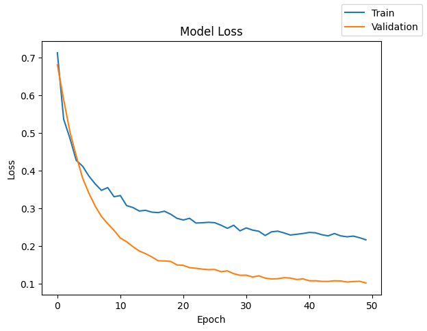

```python
# plot the loss
plot_metric(history8,'loss')
```

**Loss Graph Observations:**

- Training loss starts high (~0.71) and decreases smoothly to ~0.23, showing stable convergence
- Validation loss starts similarly (~0.71) and decreases to ~0.11, demonstrating good generalization
- Both curves converge smoothly without oscillations (compared to Model 7), indicating batch normalization stabilized training

#### Recall analysis

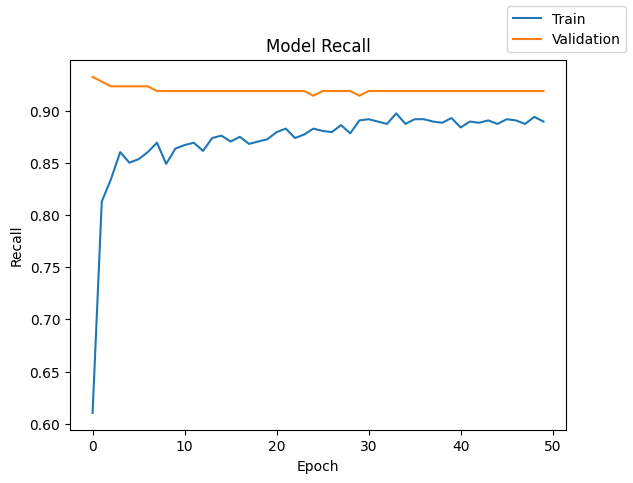

```python
# plot the recall
plot_metric(history8,'recall')
```

**Recall Graph Observations:**

- Training recall starts low (~0.61) and gradually improves to ~0.89 by epoch 50
- Validation recall starts high (~0.93) and remains stable around 0.91-0.92 throughout training
- Small gap between training (89%) and validation (91%) recall shows well-controlled overfitting

#### Confusion matrix analysis

```
500/500 ━━━━━━━━━━━━━━━━━━━━ 0s 240us/step
125/125 ━━━━━━━━━━━━━━━━━━━━ 0s 259us/step
```

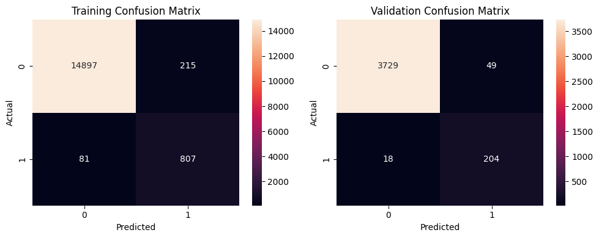

```python
# plot the confusion matrix for train and validation data
plot_confusion_matrices_v2(model8, X_train_normalized, y_train, X_val_normalized, y_val)
```

**Confusion matrix observations**

- False Negatives have reduced to 18, improving the validation recall marginally
- Higher false positives (49 vs 20 for Model 7) indicating degraded precision. These are increasing the inspection costs but the cost of replacement is of higher significance

### Model Results

```python
# Add model results to summary
results.loc[7] = ['Model 8',
    3,                              # hidden_layers
    [256, 128, 64],                 # neurons_in_hidden_layers
    ["relu", "relu", "relu"],       # activation_function_in__hidden_layer
    50,                             # epochs
    64,                             # batch_size
    "Adam",                          # optimizer
    [0.0001, "-"],                  # learning_rate, momentum
    "Xavier (aka Glorot)",          # kernel_weights_init
    "batch normalization, dropout(0.5, 0.4, 0.3)",       # regularization
    history8.history["loss"][-1],   # train_loss
    history8.history["val_loss"][-1],  # validation_loss
    history8.history["recall"][-1],    # train_recall
    history8.history["val_recall"][-1],# validation_recall
    round(end - start, 2)           # duration
]
results
```

|  | model_name | hidden_layers | hidden_layer_neurons | hidden_layer_activations | epochs | batch_size | optimizer | learning_rate, momentum | kernel_weights_init | regularization | train_loss | validation_loss | train_recall | validation_recall | duration |
| --- | --- | --- | --- | --- | --- | --- | --- | --- | --- | --- | --- | --- | --- | --- | --- |
| 0 | Model 1 | 2 | [128, 64] | [relu, relu] | 50 | 64 | SGD | [0.01, -] | Xavier (aka Glorot) | - | 0.122834 | 0.128425 | 0.918919 | 0.918919 | 6.20 |
| 1 | Model 2 | 2 | [128, 64] | [relu, relu] | 50 | 128 | SGD | [0.01, -] | Xavier (aka Glorot) | - | 0.156367 | 0.142436 | 0.914414 | 0.918919 | 4.19 |
| 2 | Model 3 | 3 | [256, 128, 64] | [relu, relu, relu] | 50 | 64 | SGD | [0.01, -] | Xavier (aka Glorot) | - | 0.073536 | 0.112700 | 0.953829 | 0.918919 | 8.36 |
| 3 | Model 4 | 3 | [256, 128, 64] | [relu, relu, relu] | 50 | 64 | SGD | [0.001, -] | Xavier (aka Glorot) | - | 0.203309 | 0.170217 | 0.906532 | 0.914414 | 8.62 |
| 4 | Model 5 | 3 | [256, 128, 64] | [relu, relu, relu] | 50 | 64 | SGD | [0.001, 0.9] | Xavier (aka Glorot) | - | 0.075856 | 0.134640 | 0.947072 | 0.918919 | 8.75 |
| 5 | Model 6 | 3 | [256, 128, 64] | [relu, relu, relu] | 50 | 64 | Adam | [0.0001, -] | Xavier (aka Glorot) | - | 0.046293 | 0.105299 | 0.978604 | 0.918919 | 9.96 |
| 6 | Model 7 | 3 | [256, 128, 64] | [relu, relu, relu] | 50 | 64 | Adam | [0.0001, -] | Xavier (aka Glorot) | dropout(0.5, 0.4, 0.3) | 0.184809 | 0.123838 | 0.908784 | 0.914414 | 11.72 |
| 7 | Model 8 | 3 | [256, 128, 64] | [relu, relu, relu] | 50 | 64 | Adam | [0.0001, -] | Xavier (aka Glorot) | batch normalization, dropout(0.5, 0.4, 0.3) | 0.216947 | 0.102477 | 0.889640 | 0.918919 | 13.96 |

## Model 9: 'He Normal' Kerner weight initialiser

```python
# clears the current Keras session, resets all layers, models previously created
tf.keras.backend.clear_session()
```

### Create Model

```python
#Initializing the neural network
model9 = Sequential()
model9.add(Input(shape=(X_train_normalized.shape[1],)))

# add 3 hidden layers with 256, 128, 64
model9.add(Dense(256,activation='relu', kernel_initializer='he_normal'))
model9.add(Dropout(0.5))

model9.add(Dense(128,activation='relu', kernel_initializer='he_normal'))
model9.add(Dropout(0.4))

model9.add(Dense(64,activation='relu', kernel_initializer='he_normal'))
model9.add(Dropout(0.3))

# sigmoid output
model9.add(Dense(1,activation='sigmoid'))
print(model9.summary())

# defining Adam optimizer. Default learning rate for Adam is 0.001
optimizer = tf.keras.optimizers.Adam(learning_rate=0.0001)

# compile with binary_crossentropy loss and Adam
model9.compile(loss='binary_crossentropy', optimizer=optimizer, metrics=['recall'])
```

```
Model: "sequential"
```

```
┏━━━━━━━━━━━━━━━━━━━━━━━━━━━━━━━━━┳━━━━━━━━━━━━━━━━━━━━━━━━┳━━━━━━━━━━━━━━━┓
┃ Layer (type)                    ┃ Output Shape           ┃       Param # ┃
┡━━━━━━━━━━━━━━━━━━━━━━━━━━━━━━━━━╇━━━━━━━━━━━━━━━━━━━━━━━━╇━━━━━━━━━━━━━━━┩
│ dense (Dense)                   │ (None, 256)            │        10,496 │
├─────────────────────────────────┼────────────────────────┼───────────────┤
│ dropout (Dropout)               │ (None, 256)            │             0 │
├─────────────────────────────────┼────────────────────────┼───────────────┤
│ dense_1 (Dense)                 │ (None, 128)            │        32,896 │
├─────────────────────────────────┼────────────────────────┼───────────────┤
│ dropout_1 (Dropout)             │ (None, 128)            │             0 │
├─────────────────────────────────┼────────────────────────┼───────────────┤
│ dense_2 (Dense)                 │ (None, 64)             │         8,256 │
├─────────────────────────────────┼────────────────────────┼───────────────┤
│ dropout_2 (Dropout)             │ (None, 64)             │             0 │
├─────────────────────────────────┼────────────────────────┼───────────────┤
│ dense_3 (Dense)                 │ (None, 1)              │            65 │
└─────────────────────────────────┴────────────────────────┴───────────────┘
```

```
 Total params: 51,713 (202.00 KB)
```

```
 Trainable params: 51,713 (202.00 KB)
```

```
 Non-trainable params: 0 (0.00 B)
```

```
None
```

### Training the model

```python
# fit the model and capture start, end times
start = time.time()
history9 = model9.fit(X_train_normalized, y_train,
                    validation_data=(X_val_normalized, y_val) ,
                    batch_size=batch_size,
                    epochs=epochs,
                    class_weight=class_weight_dict)
end=time.time()

print("Time taken in seconds ",end-start)
```

```
250/250 ━━━━━━━━━━━━━━━━━━━━ 1s 1ms/step - loss: 1.1748 - recall: 0.5598 - val_loss: 0.4078 - val_recall: 0.8108
 68/250 ━━━━━━━━━━━━━━━━━━━━ 0s 755us/step - loss: 0.7179 - recall: 0.7062
```

```
250/250 ━━━━━━━━━━━━━━━━━━━━ 0s 929us/step - loss: 0.7418 - recall: 0.7029 - val_loss: 0.4167 - val_recall: 0.8694
250/250 ━━━━━━━━━━━━━━━━━━━━ 0s 880us/step - loss: 0.7047 - recall: 0.7336 - val_loss: 0.3916 - val_recall: 0.8919
250/250 ━━━━━━━━━━━━━━━━━━━━ 0s 869us/step - loss: 0.5708 - recall: 0.8009 - val_loss: 0.3613 - val_recall: 0.9009
250/250 ━━━━━━━━━━━━━━━━━━━━ 0s 887us/step - loss: 0.5726 - recall: 0.7763 - val_loss: 0.3537 - val_recall: 0.9009
250/250 ━━━━━━━━━━━━━━━━━━━━ 0s 882us/step - loss: 0.5591 - recall: 0.8100 - val_loss: 0.3441 - val_recall: 0.9009
250/250 ━━━━━━━━━━━━━━━━━━━━ 0s 879us/step - loss: 0.5097 - recall: 0.8156 - val_loss: 0.3366 - val_recall: 0.9054
250/250 ━━━━━━━━━━━━━━━━━━━━ 0s 879us/step - loss: 0.4764 - recall: 0.8191 - val_loss: 0.3391 - val_recall: 0.9054
250/250 ━━━━━━━━━━━━━━━━━━━━ 0s 821us/step - loss: 0.4516 - recall: 0.8358 - val_loss: 0.3295 - val_recall: 0.9144
250/250 ━━━━━━━━━━━━━━━━━━━━ 0s 829us/step - loss: 0.4415 - recall: 0.8229 - val_loss: 0.3226 - val_recall: 0.9189
250/250 ━━━━━━━━━━━━━━━━━━━━ 0s 831us/step - loss: 0.4287 - recall: 0.8464 - val_loss: 0.3192 - val_recall: 0.9189
250/250 ━━━━━━━━━━━━━━━━━━━━ 0s 874us/step - loss: 0.3924 - recall: 0.8673 - val_loss: 0.3144 - val_recall: 0.9189
250/250 ━━━━━━━━━━━━━━━━━━━━ 0s 872us/step - loss: 0.4135 - recall: 0.8528 - val_loss: 0.2999 - val_recall: 0.9144
250/250 ━━━━━━━━━━━━━━━━━━━━ 0s 882us/step - loss: 0.3872 - recall: 0.8448 - val_loss: 0.3054 - val_recall: 0.9189
250/250 ━━━━━━━━━━━━━━━━━━━━ 0s 862us/step - loss: 0.3829 - recall: 0.8611 - val_loss: 0.2970 - val_recall: 0.9189
250/250 ━━━━━━━━━━━━━━━━━━━━ 0s 878us/step - loss: 0.3837 - recall: 0.8688 - val_loss: 0.3028 - val_recall: 0.9144
250/250 ━━━━━━━━━━━━━━━━━━━━ 0s 930us/step - loss: 0.3579 - recall: 0.8801 - val_loss: 0.2932 - val_recall: 0.9144
250/250 ━━━━━━━━━━━━━━━━━━━━ 0s 877us/step - loss: 0.3556 - recall: 0.8452 - val_loss: 0.2798 - val_recall: 0.9144
250/250 ━━━━━━━━━━━━━━━━━━━━ 0s 840us/step - loss: 0.3395 - recall: 0.8620 - val_loss: 0.2715 - val_recall: 0.9099
250/250 ━━━━━━━━━━━━━━━━━━━━ 0s 869us/step - loss: 0.3480 - recall: 0.8496 - val_loss: 0.2698 - val_recall: 0.9054
250/250 ━━━━━━━━━━━━━━━━━━━━ 0s 882us/step - loss: 0.3456 - recall: 0.8681 - val_loss: 0.2704 - val_recall: 0.9099
250/250 ━━━━━━━━━━━━━━━━━━━━ 0s 867us/step - loss: 0.3318 - recall: 0.8650 - val_loss: 0.2713 - val_recall: 0.9054
250/250 ━━━━━━━━━━━━━━━━━━━━ 0s 868us/step - loss: 0.3415 - recall: 0.8645 - val_loss: 0.2684 - val_recall: 0.9054
250/250 ━━━━━━━━━━━━━━━━━━━━ 0s 888us/step - loss: 0.3209 - recall: 0.8623 - val_loss: 0.2484 - val_recall: 0.9009
250/250 ━━━━━━━━━━━━━━━━━━━━ 0s 847us/step - loss: 0.3162 - recall: 0.8729 - val_loss: 0.2565 - val_recall: 0.9054
250/250 ━━━━━━━━━━━━━━━━━━━━ 0s 854us/step - loss: 0.3170 - recall: 0.8726 - val_loss: 0.2539 - val_recall: 0.9009
250/250 ━━━━━━━━━━━━━━━━━━━━ 0s 850us/step - loss: 0.3069 - recall: 0.8745 - val_loss: 0.2536 - val_recall: 0.8964
250/250 ━━━━━━━━━━━━━━━━━━━━ 0s 883us/step - loss: 0.2923 - recall: 0.8761 - val_loss: 0.2501 - val_recall: 0.9009
250/250 ━━━━━━━━━━━━━━━━━━━━ 0s 876us/step - loss: 0.2966 - recall: 0.8864 - val_loss: 0.2435 - val_recall: 0.8964
250/250 ━━━━━━━━━━━━━━━━━━━━ 0s 825us/step - loss: 0.2888 - recall: 0.8853 - val_loss: 0.2401 - val_recall: 0.8964
250/250 ━━━━━━━━━━━━━━━━━━━━ 0s 838us/step - loss: 0.2961 - recall: 0.8703 - val_loss: 0.2435 - val_recall: 0.8964
250/250 ━━━━━━━━━━━━━━━━━━━━ 0s 830us/step - loss: 0.2955 - recall: 0.8636 - val_loss: 0.2454 - val_recall: 0.8964
250/250 ━━━━━━━━━━━━━━━━━━━━ 0s 852us/step - loss: 0.2748 - recall: 0.8874 - val_loss: 0.2399 - val_recall: 0.8964
250/250 ━━━━━━━━━━━━━━━━━━━━ 0s 861us/step - loss: 0.2813 - recall: 0.8756 - val_loss: 0.2371 - val_recall: 0.8964
250/250 ━━━━━━━━━━━━━━━━━━━━ 0s 865us/step - loss: 0.2661 - recall: 0.8816 - val_loss: 0.2415 - val_recall: 0.8964
250/250 ━━━━━━━━━━━━━━━━━━━━ 0s 866us/step - loss: 0.2685 - recall: 0.8743 - val_loss: 0.2372 - val_recall: 0.8964
250/250 ━━━━━━━━━━━━━━━━━━━━ 0s 908us/step - loss: 0.2549 - recall: 0.8932 - val_loss: 0.2304 - val_recall: 0.8964
250/250 ━━━━━━━━━━━━━━━━━━━━ 0s 860us/step - loss: 0.2698 - recall: 0.8808 - val_loss: 0.2296 - val_recall: 0.8964
250/250 ━━━━━━━━━━━━━━━━━━━━ 0s 863us/step - loss: 0.2566 - recall: 0.8911 - val_loss: 0.2292 - val_recall: 0.8964
250/250 ━━━━━━━━━━━━━━━━━━━━ 0s 836us/step - loss: 0.2596 - recall: 0.8929 - val_loss: 0.2276 - val_recall: 0.8964
250/250 ━━━━━━━━━━━━━━━━━━━━ 0s 808us/step - loss: 0.2532 - recall: 0.8845 - val_loss: 0.2279 - val_recall: 0.8964
250/250 ━━━━━━━━━━━━━━━━━━━━ 0s 838us/step - loss: 0.2609 - recall: 0.8916 - val_loss: 0.2309 - val_recall: 0.8964
250/250 ━━━━━━━━━━━━━━━━━━━━ 0s 799us/step - loss: 0.2365 - recall: 0.8978 - val_loss: 0.2312 - val_recall: 0.8964
250/250 ━━━━━━━━━━━━━━━━━━━━ 0s 804us/step - loss: 0.2426 - recall: 0.8812 - val_loss: 0.2284 - val_recall: 0.8964
250/250 ━━━━━━━━━━━━━━━━━━━━ 0s 796us/step - loss: 0.2448 - recall: 0.8895 - val_loss: 0.2136 - val_recall: 0.8964
250/250 ━━━━━━━━━━━━━━━━━━━━ 0s 795us/step - loss: 0.2453 - recall: 0.8760 - val_loss: 0.2194 - val_recall: 0.8964
250/250 ━━━━━━━━━━━━━━━━━━━━ 0s 785us/step - loss: 0.2371 - recall: 0.8849 - val_loss: 0.2150 - val_recall: 0.8964
250/250 ━━━━━━━━━━━━━━━━━━━━ 0s 804us/step - loss: 0.2270 - recall: 0.8930 - val_loss: 0.2119 - val_recall: 0.8964
250/250 ━━━━━━━━━━━━━━━━━━━━ 0s 840us/step - loss: 0.2496 - recall: 0.8870 - val_loss: 0.2164 - val_recall: 0.8964
250/250 ━━━━━━━━━━━━━━━━━━━━ 0s 854us/step - loss: 0.2499 - recall: 0.8861 - val_loss: 0.2127 - val_recall: 0.8964
Time taken in seconds  11.524345874786377
```

### Model Analysis

#### Loss analysis

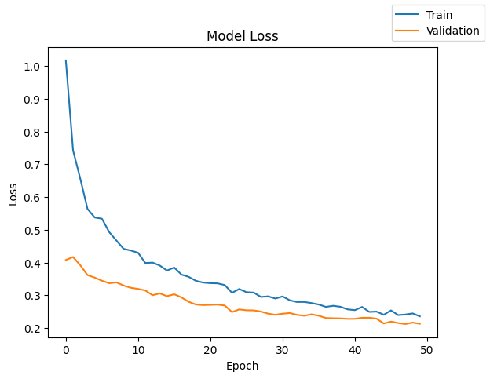

```python
# plot the loss
plot_metric(history9,'loss')
```

**Loss Graph Observations:**

#### Recall analysis

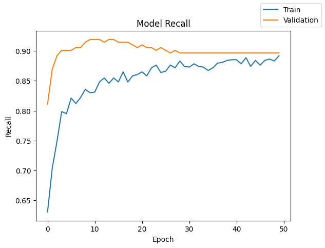

```python
# plot the recall
plot_metric(history9,'recall')
```

**Recall Graph Observations:**

- Training recall starts low (~0.63) and gradually improves to ~0.88 by epoch 50
- Validation recall starts higher (~0.82) and plateaus around 0.90-0.91 after epoch 30
- Validation recall consistently outperforms training recall throughout training

#### Confusion matrix analysis

```
500/500 ━━━━━━━━━━━━━━━━━━━━ 0s 222us/step
125/125 ━━━━━━━━━━━━━━━━━━━━ 0s 250us/step
```

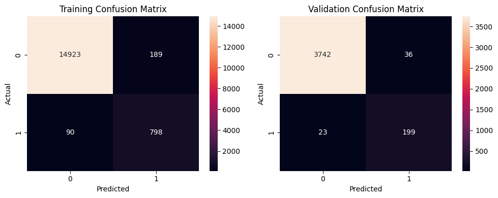

```python
# plot the confusion matrix for train and validation data
plot_confusion_matrices_v2(model9, X_train_normalized, y_train, X_val_normalized, y_val)
```

**Confusion matrix observations**

### Model Results

```python
# Add model results to summary
results.loc[8] = ['Model 9',
    3,                              # hidden_layers
    [256, 128, 64],                 # neurons_in_hidden_layers
    ["relu", "relu", "relu"],       # activation_function_in__hidden_layer
    50,                             # epochs
    64,                             # batch_size
    "Adam",                         # optimizer
    [0.0001, "-"],                  # learning_rate, momentum
    "He Normal",                    # kernel_weights_init
    "dropout(0.5, 0.4, 0.3)",       # regularization
    history9.history["loss"][-1],   # train_loss
    history9.history["val_loss"][-1],  # validation_loss
    history9.history["recall"][-1],    # train_recall
    history9.history["val_recall"][-1],# validation_recall
    round(end - start, 2)           # duration
]
results
```

|  | model_name | hidden_layers | hidden_layer_neurons | hidden_layer_activations | epochs | batch_size | optimizer | learning_rate, momentum | kernel_weights_init | regularization | train_loss | validation_loss | train_recall | validation_recall | duration |
| --- | --- | --- | --- | --- | --- | --- | --- | --- | --- | --- | --- | --- | --- | --- | --- |
| 0 | Model 1 | 2 | [128, 64] | [relu, relu] | 50 | 64 | SGD | [0.01, -] | Xavier (aka Glorot) | - | 0.122834 | 0.128425 | 0.918919 | 0.918919 | 6.20 |
| 1 | Model 2 | 2 | [128, 64] | [relu, relu] | 50 | 128 | SGD | [0.01, -] | Xavier (aka Glorot) | - | 0.156367 | 0.142436 | 0.914414 | 0.918919 | 4.19 |
| 2 | Model 3 | 3 | [256, 128, 64] | [relu, relu, relu] | 50 | 64 | SGD | [0.01, -] | Xavier (aka Glorot) | - | 0.073536 | 0.112700 | 0.953829 | 0.918919 | 8.36 |
| 3 | Model 4 | 3 | [256, 128, 64] | [relu, relu, relu] | 50 | 64 | SGD | [0.001, -] | Xavier (aka Glorot) | - | 0.203309 | 0.170217 | 0.906532 | 0.914414 | 8.62 |
| 4 | Model 5 | 3 | [256, 128, 64] | [relu, relu, relu] | 50 | 64 | SGD | [0.001, 0.9] | Xavier (aka Glorot) | - | 0.075856 | 0.134640 | 0.947072 | 0.918919 | 8.75 |
| 5 | Model 6 | 3 | [256, 128, 64] | [relu, relu, relu] | 50 | 64 | Adam | [0.0001, -] | Xavier (aka Glorot) | - | 0.046293 | 0.105299 | 0.978604 | 0.918919 | 9.96 |
| 6 | Model 7 | 3 | [256, 128, 64] | [relu, relu, relu] | 50 | 64 | Adam | [0.0001, -] | Xavier (aka Glorot) | dropout(0.5, 0.4, 0.3) | 0.184809 | 0.123838 | 0.908784 | 0.914414 | 11.72 |
| 7 | Model 8 | 3 | [256, 128, 64] | [relu, relu, relu] | 50 | 64 | Adam | [0.0001, -] | Xavier (aka Glorot) | batch normalization, dropout(0.5, 0.4, 0.3) | 0.216947 | 0.102477 | 0.889640 | 0.918919 | 13.96 |
| 8 | Model 9 | 3 | [256, 128, 64] | [relu, relu, relu] | 50 | 64 | Adam | [0.0001, -] | He Normal | dropout(0.5, 0.4, 0.3) | 0.235318 | 0.212672 | 0.891892 | 0.896396 | 11.52 |

## Best Model Selection

### Listing the model performances

```python
#print the results
results
```

|  | model_name | hidden_layers | hidden_layer_neurons | hidden_layer_activations | epochs | batch_size | optimizer | learning_rate, momentum | kernel_weights_init | regularization | train_loss | validation_loss | train_recall | validation_recall | duration |
| --- | --- | --- | --- | --- | --- | --- | --- | --- | --- | --- | --- | --- | --- | --- | --- |
| 0 | Model 1 | 2 | [128, 64] | [relu, relu] | 50 | 64 | SGD | [0.01, -] | Xavier (aka Glorot) | - | 0.122834 | 0.128425 | 0.918919 | 0.918919 | 6.20 |
| 1 | Model 2 | 2 | [128, 64] | [relu, relu] | 50 | 128 | SGD | [0.01, -] | Xavier (aka Glorot) | - | 0.156367 | 0.142436 | 0.914414 | 0.918919 | 4.19 |
| 2 | Model 3 | 3 | [256, 128, 64] | [relu, relu, relu] | 50 | 64 | SGD | [0.01, -] | Xavier (aka Glorot) | - | 0.073536 | 0.112700 | 0.953829 | 0.918919 | 8.36 |
| 3 | Model 4 | 3 | [256, 128, 64] | [relu, relu, relu] | 50 | 64 | SGD | [0.001, -] | Xavier (aka Glorot) | - | 0.203309 | 0.170217 | 0.906532 | 0.914414 | 8.62 |
| 4 | Model 5 | 3 | [256, 128, 64] | [relu, relu, relu] | 50 | 64 | SGD | [0.001, 0.9] | Xavier (aka Glorot) | - | 0.075856 | 0.134640 | 0.947072 | 0.918919 | 8.75 |
| 5 | Model 6 | 3 | [256, 128, 64] | [relu, relu, relu] | 50 | 64 | Adam | [0.0001, -] | Xavier (aka Glorot) | - | 0.046293 | 0.105299 | 0.978604 | 0.918919 | 9.96 |
| 6 | Model 7 | 3 | [256, 128, 64] | [relu, relu, relu] | 50 | 64 | Adam | [0.0001, -] | Xavier (aka Glorot) | dropout(0.5, 0.4, 0.3) | 0.184809 | 0.123838 | 0.908784 | 0.914414 | 11.72 |
| 7 | Model 8 | 3 | [256, 128, 64] | [relu, relu, relu] | 50 | 64 | Adam | [0.0001, -] | Xavier (aka Glorot) | batch normalization, dropout(0.5, 0.4, 0.3) | 0.216947 | 0.102477 | 0.889640 | 0.918919 | 13.96 |
| 8 | Model 9 | 3 | [256, 128, 64] | [relu, relu, relu] | 50 | 64 | Adam | [0.0001, -] | He Normal | dropout(0.5, 0.4, 0.3) | 0.235318 | 0.212672 | 0.891892 | 0.896396 | 11.52 |

### Best Model : 'Model 8'

Model 8 is the best model based on comprehensive evaluation

### Other Models

Why other models were not chosen ?

**Model 7:**

- Close second with good recall (91.4%) but training instability and oscillations exist

**Model 3, 5, 6:**

- Strong training performance but clear, visible overfitting on all models and model 5 has convergence issues

Models 4 & 9:

- Poor validation recall (91.4% and 89.6%) - insufficient failure detection for critical applications

**Model 1:**

- Tied highest validation recall (91.9%) with perfect generalization but too simplistic for complex failure patterns

### 'Model 8' performance on test data

#### Recall score on Test data

- The model8 will be used to predict the test_data
- Test data is already imputed for nulls and also scaled
- Corresponding Training and validation Recll scores of 'Model 8' will be obtained from history of the model

```python
# clears the current Keras session, resets all layers, models previously created
tf.keras.backend.clear_session()
```

```python
# predict y_test
y_test_pred = (model8.predict(X_test_normalized) > 0.5).astype(int)
```

```
157/157 ━━━━━━━━━━━━━━━━━━━━ 0s 305us/step
```

```python
# get the testing recall_score from model8
model8_test_recall = recall_score(y_test, y_test_pred)

# get the training and validation recall from model8 history
model8_train_recall = history8.history['recall'][-1]
model8_val_recall = history8.history['val_recall'][-1]

# Print all the recall values
print(f"Training Recall:    {model8_train_recall:.4f}")
print(f"Validation Recall:    {model8_val_recall:.4f}")
print(f"Test Recall:    {model8_test_recall:.4f}")
```

```
Training Recall:    0.8896
Validation Recall:    0.9189
Test Recall:    0.8723
```

**Observations from test data prediction:**

1. High Recall Across All Sets
   - All recall scores are above 87%. The model identified ~87% of expensive replacements and only 13% go undetected.
2. No Overfitting
   - Training recall (88.96%) is actually lower than validation recall (91.89%) This suggests the model is not memorizing the training data
3. Good Generalization
   - Small validation-to-test gap: 91.89% → 87.23% = 4.66% difference This indicates the model *generalizes reasonably well* to unseen data

#### Confusion matrix for test data

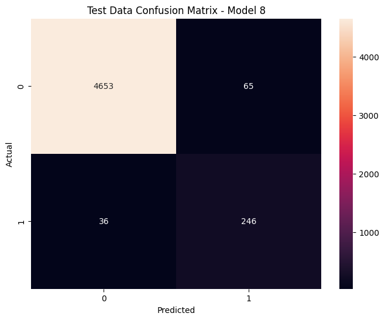

```python
#Plot the confusion matrix for test data
model8_cm_test = confusion_matrix(y_test, y_test_pred)
plt.figure(figsize=(8, 6))
sns.heatmap(model8_cm_test, annot=True, fmt='')
plt.title('Test Data Confusion Matrix - Model 8')
plt.ylabel('Actual')
plt.xlabel('Predicted')
plt.show()
```

**confusion matrix observations**

- False Negative is 36 implying 12.7% failures go undetected leading to replacement costs. It also implies 87.3% are detected leading to **huge savings for wind turbine machinery owning businesses**
- False Positive is 65 and is less, implying **Minimal unnecessary inspection costs**

# **5. Actionable Insights & Recommendations**

## Key Highlights

1. **Deploy Model 8**
   - The model (Model 8) achieves 87% recall with 79% precision, delivering ~78% cost reduction
2. **Focus monitoring on high-risk features**
   - In EDA it was obserbved that V18, V21, V15, V7 show strongest correlation (0.24-0.27) with failures and should be prioritized in sensor maintenance
3. **Implement risk-based maintenance scheduling**
   - The Model identifies '246 turbines needing repair' vs '36 emergency replacements', enabling proactive intervention
4. **Establish feature importance monitoring**
   - Track V3, V28, V11 (negative predictors) as protective factors that indicate healthy turbine operation. This was also observed in EDA
5. **Consider threshold optimization**
   - Current model balances costs well, but threshold tuning could push recall to 90%+ if replacement costs justify higher inspection rates
6. **Scale neural network approach**
   - Model 8's batch normalization + dropout architecture proves optimal for this imbalanced dataset and can be template for similar predictive maintenance problems

## Detailed Recommendations

- **Deployment Strategy**: Model 8 demonstrates production-ready performance with excellent cost-effectiveness. The 87% recall rate means only 36 out of 282 failures go undetected, while 79% precision keeps false alarms manageable at just 65 cases. This translates to preventing catastrophic replacements for 246 turbines while maintaining operational efficiency.
- **Feature-Based Maintenance Protocol**: Implement enhanced monitoring for the top predictive features identified through correlation analysis. Variables V18 and V21 showing 0.25-0.27 correlation with failures should trigger immediate inspection protocols when values exceed normal ranges. Conversely, declining values in protective features (V3, V28, V11) should prompt preventive maintenance scheduling.
- **Model Architecture Standardization**: The successful combination of batch normalization with progressive dropout (0.5→0.4→0.3) in Model 8 provides a robust template for future predictive maintenance models. This architecture effectively handles the 5.55% class imbalance while maintaining generalization, as evidenced by consistent performance across train (88.96%), validation (91.89%), and test (87.23%) sets.

## Key limitations of the Model ('Model 8')

It is also very important to understand the limitations of the model.

1. **13% of critical failures still undetected.**
   - 36 turbines will fail unexpectedly, resulting in costly emergency replacements and potential downtime
2. **Relies on historical failure patterns only**
   - Model cannot predict new types of failures or equipment degradation patterns not seen in training data
3. **Sensor dependency risk
   - Model effectiveness degrades if any of the 40 sensors malfunction, get miscalibrated, or experience data quality issues
4. **No failure timeline prediction**
   - Model identifies "will fail" but not "when will fail," limiting maintenance scheduling precision
5. **Static decision threshold**
   - Fixed 0.5 probability threshold may not be optimal across different seasons, turbine ages, or operating conditions

Power Ahead